# Credit Risk Modeling in Python: Case Study

Date: May 03, 2020

Student: Armand Tossou

Class: Advanced Financial Modeling & Theory

## Overview

I use state of the art techniques to model all three aspects of the total expected loss (EL) equation for the bank:

- probability of default (PD)
- loss given default (LDG)
- exposure at default (EAD)

This complete data science case study in Python covers:

- data preprocessing
- data modeling
- model validation and maintenance
- and prediction

I create a **scorecard** from scratch, based on the estimated PD coefficients.

These models are compliant with Basel II and Basel III regulations.

## Data

The dataset used in this credit risk modeling project is an actual real-world example from The Lending Club. This financial institution does peer-to-peer lending and alternative investing. Their product lins cover personal loans, auto refinancing loans, business loans, and medical financing. Website: www.lendingclub.com (see below for more detail).

## Import Data

The dataset contains all available data for more than 800,000 consumer loans issued from 2007 to 2015 by Lending Club: a large US peer-to-peer lending company. There are several different versions of this dataset. I have used a version available on kaggle.com. You can find it here: https://www.kaggle.com/wendykan/lending-club-loan-data/version/1

I divided the data into two periods because I assume that some data are available at the moment when I need to build Expected Loss models, and some data come from applications after. Later, I investigate whether the applications I have after building the Probability of Default (PD) model have similar characteristics with the applications I used to build the PD model.

# 1. Data Preparation

## Import required libraries and Dataset

```python
import numpy as np
import pandas as pd
# ignore warnings
import warnings
warnings.filterwarnings("ignore")
```

```python
## load the dataset
loan_data_backup = pd.read_csv('loan_data_2007_2014.csv')
```

```python
## make a copy of the dataset (and keep the original dataset untouched)
loan_data = loan_data_backup.copy()
```

## Preview and Explore the Data

```python
# Sets the pandas dataframe options to display all columns/ rows.
pd.options.display.max_columns = None
#pd.options.display.max_rows = None
```

```python
## Preview the dataset
# loan_data.head()
# loan_data.tail()
loan_data.sample(10)
```

|  | Unnamed: 0 | id | member_id | loan_amnt | funded_amnt | funded_amnt_inv | term | int_rate | installment | grade | sub_grade | emp_title | emp_length | home_ownership | annual_inc | verification_status | issue_d | loan_status | pymnt_plan | url | desc | purpose | title | zip_code | addr_state | dti | delinq_2yrs | earliest_cr_line | inq_last_6mths | … |
| --- | --- | --- | --- | --- | --- | --- | --- | --- | --- | --- | --- | --- | --- | --- | --- | --- | --- | --- | --- | --- | --- | --- | --- | --- | --- | --- | --- | --- | --- | --- |
| 130817 | 130817 | 5628028 | 7010372 | 3450 | 3450 | 3450.0 | 36 months | 11.14 | 113.18 | B | B2 | NaN | NaN | MORTGAGE | 22000.0 | Verified | Jun-13 | Fully Paid | n | https://www.lendingclub.com/browse/loanDetail.... | NaN | debt_consolidation | loan | 922xx | CA | 21.65 | 0.0 | Oct-82 | 0.0 | … |
| 364470 | 364470 | 16472047 | 18554525 | 13150 | 13150 | 13150.0 | 60 months | 16.99 | 326.75 | D | D3 | Marketing Developement | 4 years | RENT | 50000.0 | Source Verified | Jun-14 | Current | n | https://www.lendingclub.com/browse/loanDetail.... | NaN | debt_consolidation | Debt consolidation | 852xx | AZ | 23.50 | 0.0 | Oct-05 | 0.0 | … |
| 86888 | 86888 | 7339416 | 9001394 | 25000 | 25000 | 25000.0 | 60 months | 17.10 | 622.66 | C | C5 | Southbury Tree Service, INC | 4 years | MORTGAGE | 73000.0 | Verified | Sep-13 | Current | n | https://www.lendingclub.com/browse/loanDetail.... | NaN | debt_consolidation | Freedom From Debt | 067xx | CT | 18.61 | 1.0 | Jul-81 | 1.0 | … |
| 463618 | 463618 | 10181215 | 12032583 | 8325 | 8325 | 8325.0 | 36 months | 16.99 | 296.77 | D | D1 | Sr. Sales and Marketing Analyst | 2 years | RENT | 75000.0 | Not Verified | Jan-14 | Fully Paid | n | https://www.lendingclub.com/browse/loanDetail.... | NaN | debt_consolidation | Consolidation Loan | 902xx | CA | 27.42 | 1.0 | Sep-04 | 1.0 | … |
| 192300 | 192300 | 1600525 | 1871385 | 5500 | 5500 | 5500.0 | 36 months | 10.16 | 177.89 | B | B1 | North Carolina State University | 2 years | RENT | 35000.0 | Verified | Oct-12 | Fully Paid | n | https://www.lendingclub.com/browse/loanDetail.... | Borrower added on 10/09/12 > I have very lit... | small_business | Business | 276xx | NC | 3.05 | 0.0 | Aug-08 | 0.0 | … |
| 447219 | 447219 | 11604641 | 13576794 | 7000 | 7000 | 7000.0 | 36 months | 13.98 | 239.18 | C | C1 | General Manager | 5 years | RENT | 58000.0 | Verified | Feb-14 | Fully Paid | n | https://www.lendingclub.com/browse/loanDetail.... | NaN | credit_card | Credit card refinancing | 916xx | CA | 24.73 | 0.0 | Jan-98 | 0.0 | … |
| 388198 | 388198 | 16482091 | 18574553 | 16375 | 16375 | 16375.0 | 36 months | 13.98 | 559.50 | C | C3 | Site Manager | 3 years | MORTGAGE | 40000.0 | Verified | May-14 | Fully Paid | n | https://www.lendingclub.com/browse/loanDetail.... | NaN | debt_consolidation | Debt consolidation | 466xx | IN | 25.32 | 0.0 | Nov-01 | 0.0 | … |
| 85774 | 85774 | 7381538 | 9043460 | 4450 | 4450 | 4450.0 | 36 months | 14.30 | 152.74 | C | C1 | owen's &minor | 6 years | RENT | 32000.0 | Verified | Oct-13 | Current | n | https://www.lendingclub.com/browse/loanDetail.... | Borrower added on 09/23/13 > hello I am tryi... | debt_consolidation | credit card | 770xx | TX | 33.90 | 0.0 | May-03 | 1.0 | … |
| 112559 | 112559 | 6309839 | 7841174 | 26250 | 26250 | 26250.0 | 60 months | 24.89 | 768.79 | F | F4 | American Express Co | 10+ years | MORTGAGE | 114000.0 | Verified | Jul-13 | Fully Paid | n | https://www.lendingclub.com/browse/loanDetail.... | Borrower added on 07/15/13 > To consolidate ... | debt_consolidation | Debt consolidation | 863xx | AZ | 21.76 | 1.0 | Apr-99 | 2.0 | … |
| 395602 | 395602 | 14680271 | 16742578 | 10000 | 10000 | 10000.0 | 60 months | 16.59 | 246.33 | D | D1 | Nurses Aid | 5 years | MORTGAGE | 45000.0 | Not Verified | May-14 | Current | n | https://www.lendingclub.com/browse/loanDetail.... | NaN | debt_consolidation | Debt consolidation | 490xx | MI | 21.33 | 1.0 | Aug-95 | 2.0 | … |

```python
## Displays all column names.
loan_data.columns.values
```

```
array(['Unnamed: 0', 'id', 'member_id', 'loan_amnt', 'funded_amnt',
       'funded_amnt_inv', 'term', 'int_rate', 'installment', 'grade',
       'sub_grade', 'emp_title', 'emp_length', 'home_ownership',
       'annual_inc', 'verification_status', 'issue_d', 'loan_status',
       'pymnt_plan', 'url', 'desc', 'purpose', 'title', 'zip_code',
       'addr_state', 'dti', 'delinq_2yrs', 'earliest_cr_line',
       'inq_last_6mths', 'mths_since_last_delinq',
       'mths_since_last_record', 'open_acc', 'pub_rec', 'revol_bal',
       'revol_util', 'total_acc', 'initial_list_status', 'out_prncp',
       'out_prncp_inv', 'total_pymnt', 'total_pymnt_inv',
       'total_rec_prncp', 'total_rec_int', 'total_rec_late_fee',
       'recoveries', 'collection_recovery_fee', 'last_pymnt_d',
       'last_pymnt_amnt', 'next_pymnt_d', 'last_credit_pull_d',
       'collections_12_mths_ex_med', 'mths_since_last_major_derog',
       'policy_code', 'application_type', 'annual_inc_joint', 'dti_joint',
       'verification_status_joint', 'acc_now_delinq', 'tot_coll_amt',
       'tot_cur_bal', 'open_acc_6m', 'open_il_6m', 'open_il_12m',
       'open_il_24m', 'mths_since_rcnt_il', 'total_bal_il', 'il_util',
       'open_rv_12m', 'open_rv_24m', 'max_bal_bc', 'all_util',
       'total_rev_hi_lim', 'inq_fi', 'total_cu_tl', 'inq_last_12m'],
      dtype=object)
```

```python
## How many observations and variables are there in this dataset?
loan_data.shape
```

```
(466285, 75)
```

```python
## Displays column names, complete (non-missing) cases per column, and datatype per column.
loan_data.info()
```

```
<class 'pandas.core.frame.DataFrame'>
RangeIndex: 466285 entries, 0 to 466284
Data columns (total 75 columns):
 #   Column                       Non-Null Count   Dtype
---  ------                       --------------   -----
 0   Unnamed: 0                   466285 non-null  int64
 1   id                           466285 non-null  int64
 2   member_id                    466285 non-null  int64
 3   loan_amnt                    466285 non-null  int64
 4   funded_amnt                  466285 non-null  int64
 5   funded_amnt_inv              466285 non-null  float64
 6   term                         466285 non-null  object
 7   int_rate                     466285 non-null  float64
 8   installment                  466285 non-null  float64
 9   grade                        466285 non-null  object
```

[output cut: 67 more lines]

## Preprocessing a Few Continuous Variables

#### Investigating the 'employment length in years' variable

```python
## Displays unique values of a column.
loan_data['emp_length'].unique()
```

```
array(['10+ years', '< 1 year', '1 year', '3 years', '8 years', '9 years',
       '4 years', '5 years', '6 years', '2 years', '7 years', nan],
      dtype=object)
```

```python
# We store the preprocessed ‘employment length’ variable in a new variable called ‘employment length int’,
# We assign the new ‘employment length int’ to be equal to the ‘employment length’ variable with the string ‘+ years’
# replaced with nothing. Next, we replace the whole string ‘less than 1 year’ with the string ‘0’.
# Then, we replace the ‘n/a’ string with the string ‘0’. Then, we replace the string ‘space years’ with nothing.
# Finally, we replace the string ‘space year’ with nothing.
loan_data['emp_length_int'] = loan_data['emp_length'].str.replace('\+ years', '')
loan_data['emp_length_int'] = loan_data['emp_length_int'].str.replace('< 1 year', str(0))
loan_data['emp_length_int'] = loan_data['emp_length_int'].str.replace('n/a',  str(0))
loan_data['emp_length_int'] = loan_data['emp_length_int'].str.replace(' years', '')
loan_data['emp_length_int'] = loan_data['emp_length_int'].str.replace(' year', '')
```

```python
# Checks the datatype of a single element of a column.
type(loan_data['emp_length_int'][0])
```

```
str
```

```python
# Transforms the values to numeric.
loan_data['emp_length_int'] = pd.to_numeric(loan_data['emp_length_int'])
```

```python
# Checks the datatype of a single element of a column.
type(loan_data['emp_length_int'][0])
```

```
numpy.float64
```

#### Investigating the variable for: the month the borrower's earliest reported credit line was opened

```python
# Displays a column.
# this is a string variable that we need to convert to a Date object.
loan_data['earliest_cr_line']
```

```
0         Jan-85
1         Apr-99
2         Nov-01
3         Feb-96
4         Jan-96
           ...
466280    Apr-03
466281    Jun-97
466282    Dec-01
466283    Feb-03
466284    Feb-00
Name: earliest_cr_line, Length: 466285, dtype: object
```

```python
# Extracts the date and the time from a string variable that is in a given format.
# assign this to a new variable 'earliest_cr_line_date'
# this is a string variable that we need to convert to a Date object.
# Ref.: https://www.datacamp.com/community/tutorials/converting-strings-datetime-objects
loan_data['earliest_cr_line_date'] = pd.to_datetime(loan_data['earliest_cr_line'], format = '%b-%y')
```

```python
# Checks the datatype of a single element of a column.
type(loan_data['earliest_cr_line_date'][0])
```

```
pandas._libs.tslibs.timestamps.Timestamp
```

```python
# just previewing a few observations
loan_data['earliest_cr_line_date'].sample(8)
```

```
161162   2002-06-01
118336   2003-09-01
220479   2002-08-01
419229   2005-02-01
91904    1992-03-01
85350    1986-04-01
308909   2002-08-01
155144   1986-01-01
Name: earliest_cr_line_date, dtype: datetime64[ns]
```

```python
# Calculates the difference between two dates and times.
pd.to_datetime('2020-12-31') - loan_data['earliest_cr_line_date']
```

```
0        13148 days
1         7945 days
2         7000 days
3         9100 days
4         9131 days
            ...
466280    6484 days
466281    8614 days
466282    6970 days
466283    6543 days
466284    7639 days
Name: earliest_cr_line_date, Length: 466285, dtype: timedelta64[ns]
```

```python
# Assume we are now on December 31, 2020
# We calculate the difference between two dates in months, turn it to numeric datatype and round it.
# We save the result in a new variable: 'mths_since_earliest_cr_line'.
loan_data['mths_since_earliest_cr_line'] = round(pd.to_numeric((pd.to_datetime('2020-12-31') - loan_data['earliest_cr_line_date']) / np.timedelta64(1, 'M')))
```

```python
# Shows some descriptive statisics for the values of a column.
# Dates from 1969 and before are not being converted well, i.e., they have become 2069 and similar,
# and negative differences are being calculated.
loan_data['mths_since_earliest_cr_line'].describe()
```

```
count    466256.000000
mean        276.482430
std          93.974829
min        -575.000000
25%         220.000000
50%         262.000000
75%         322.000000
max         624.000000
Name: mths_since_earliest_cr_line, dtype: float64
```

```python
# We take three columns from the dataframe. Then, we display them only for the rows where a variable has negative value.
# There are 1169 strange negative values.
loan_data.loc[: , ['earliest_cr_line', 'earliest_cr_line_date', 'mths_since_earliest_cr_line']][loan_data['mths_since_earliest_cr_line'] < 0]
```

|  | earliest_cr_line | earliest_cr_line_date | mths_since_earliest_cr_line |
| --- | --- | --- | --- |
| 1580 | Sep-62 | 2062-09-01 | -500.0 |
| 1770 | Sep-68 | 2068-09-01 | -572.0 |
| 2799 | Sep-64 | 2064-09-01 | -524.0 |
| 3282 | Sep-67 | 2067-09-01 | -560.0 |
| 3359 | Feb-65 | 2065-02-01 | -529.0 |
| ... | ... | ... | ... |
| 464003 | Jan-68 | 2068-01-01 | -564.0 |
| 464260 | Jul-66 | 2066-07-01 | -546.0 |
| 465100 | Oct-67 | 2067-10-01 | -561.0 |
| 465500 | Sep-67 | 2067-09-01 | -560.0 |
| 465655 | Jan-56 | 2056-01-01 | -420.0 |

1169 rows × 3 columns

```python
# Python added 100 years to those rows. Here's an example:
2062 - 1962
```

```
100
```

```python
# Let's subtract 100 years from the rows with negative values
# so we compute the 'earliest_cr_line_date' variable again (replacing the new one with the old one)
loan_data['earliest_cr_line_date'][loan_data['mths_since_earliest_cr_line'] < 0] = loan_data['earliest_cr_line_date'] - np.timedelta64(100, 'Y')
# display the column again
loan_data['earliest_cr_line_date'][loan_data['mths_since_earliest_cr_line'] < 0]
```

```
1580     1962-09-01 18:00:00
1770     1968-09-01 18:00:00
2799     1964-09-01 18:00:00
3282     1967-09-01 18:00:00
3359     1965-02-01 18:00:00
                 ...
464003   1968-01-01 18:00:00
464260   1966-07-01 18:00:00
465100   1967-10-01 18:00:00
465500   1967-09-01 18:00:00
465655   1956-01-01 18:00:00
Name: earliest_cr_line_date, Length: 1169, dtype: datetime64[ns]
```

Everythong looks great now :)

So let's compute our 'mths_since_earliest_cr_line' variable again, by replacing the new one with the old one. We use the same code as above:

```python
# Assume we are now on December 31, 2020
# We calculate the difference between two dates in months, turn it to numeric datatype and round it.
# We save the result in a new variable: 'mths_since_earliest_cr_line'.
loan_data['mths_since_earliest_cr_line'] = round(pd.to_numeric((pd.to_datetime('2020-12-31') - loan_data['earliest_cr_line_date']) / np.timedelta64(1, 'M')))
```

```python
# Shows some descriptive statisics for the values of a column.
# Everything looks great now!
loan_data['mths_since_earliest_cr_line'].describe()
```

```
count    466256.000000
mean        279.491078
std          86.928944
min         110.000000
25%         221.000000
50%         263.000000
75%         322.000000
max         924.000000
Name: mths_since_earliest_cr_line, dtype: float64
```

The minimum value is now 110 months. Great!

NOTE : Another way to deal with this problem with negative date values could have been to just set the rows that had negative differences to the maximum value. See code below:

`loan_data['mths_since_earliest_cr_line'][loan_data['mths_since_earliest_cr_line'] < 0] = loan_data['mths_since_earliest_cr_line'].max()`

```python
#loan_data['mths_since_earliest_cr_line'][loan_data['mths_since_earliest_cr_line'] < 0] = loan_data['mths_since_earliest_cr_line'].max()
```

```python
# Calculates and shows the minimum value of a column.
#min(loan_data['mths_since_earliest_cr_line_2'])
```

#### Investigating the variable for: the number of payments on the loan (values are in months and can be either 36 or 60)

```python
# preview this variable
loan_data['term']
```

```
0          36 months
1          60 months
2          36 months
3          36 months
4          60 months
             ...
466280     60 months
466281     60 months
466282     60 months
466283     36 months
466284     36 months
Name: term, Length: 466285, dtype: object
```

```python
# Shows some descriptive statisics for the values of a column.
loan_data['term'].describe()
```

```
count         466285
unique             2
top        36 months
freq          337953
Name: term, dtype: object
```

```python
# Shows unique values of this column.
loan_data['term'].unique()
```

```
array([' 36 months', ' 60 months'], dtype=object)
```

```python
# Let's remove the 'months' in order to convert this variable to numeric
# First, we replace the string with another string, in this case, with an empty strng (i.e. with nothing).
# Next, we convert the result to numeric values
# Finally, we save the result to a new variable: 'term_int'
loan_data['term_int'] = pd.to_numeric(loan_data['term'].str.replace(' months', ''))
```

```python
loan_data['term_int']
```

```
0         36
1         60
2         36
3         36
4         60
          ..
466280    60
466281    60
466282    60
466283    36
466284    36
Name: term_int, Length: 466285, dtype: int64
```

#### Investigating the variable for: The month which the loan was funded

```python
loan_data['issue_d']
```

```
0         Dec-11
1         Dec-11
2         Dec-11
3         Dec-11
4         Dec-11
           ...
466280    Jan-14
466281    Jan-14
466282    Jan-14
466283    Jan-14
466284    Jan-14
Name: issue_d, Length: 466285, dtype: object
```

```python
# Assume we are now in December 2020
# Extracts the date and the time from a string variable that is in a given format.
# See: https://www.datacamp.com/community/tutorials/converting-strings-datetime-objects
## Save the result in a new variable: 'issue_d_date'
loan_data['issue_d_date'] = pd.to_datetime(loan_data['issue_d'], format = '%b-%y')
# We calculate the difference between two dates in months, turn it to numeric datatype and round it.
# We save the result in a new variable: 'mths_since_issue_d'.
loan_data['mths_since_issue_d'] = round(pd.to_numeric((pd.to_datetime('2020-12-31') - loan_data['issue_d_date']) / np.timedelta64(1, 'M')))
# Shows some descriptive statisics for the values of the new variable.
loan_data['mths_since_issue_d'].describe()
```

```
count    466285.000000
mean         88.255187
std          14.340154
min          73.000000
25%          78.000000
50%          84.000000
75%          94.000000
max         163.000000
Name: mths_since_issue_d, dtype: float64
```

Everything looks find; no weird negative values. Great!

### Preprocessing a few Discrete Variables

```python
# Displays column names, complete (non-missing) cases per column, and datatype per column.
loan_data.info()
```

```
<class 'pandas.core.frame.DataFrame'>
RangeIndex: 466285 entries, 0 to 466284
Data columns (total 81 columns):
 #   Column                       Non-Null Count   Dtype
---  ------                       --------------   -----
 0   Unnamed: 0                   466285 non-null  int64
 1   id                           466285 non-null  int64
 2   member_id                    466285 non-null  int64
 3   loan_amnt                    466285 non-null  int64
 4   funded_amnt                  466285 non-null  int64
 5   funded_amnt_inv              466285 non-null  float64
 6   term                         466285 non-null  object
 7   int_rate                     466285 non-null  float64
 8   installment                  466285 non-null  float64
 9   grade                        466285 non-null  object
```

[output cut: 73 more lines]

We are going to preprocess the following discrete variables: grade, sub_grade, home_ownership, verification_status, loan_status, purpose, addr_state, initial_list_status. Most likely, we are not going to use sub_grade, as it overlaps with grade.

#### Processing the 'grade' variable

```python
# Create dummy variables from a variable.
pd.get_dummies(loan_data['grade'])
```

|  | A | B | C | D | E | F | G |
| --- | --- | --- | --- | --- | --- | --- | --- |
| 0 | 0 | 1 | 0 | 0 | 0 | 0 | 0 |
| 1 | 0 | 0 | 1 | 0 | 0 | 0 | 0 |
| 2 | 0 | 0 | 1 | 0 | 0 | 0 | 0 |
| 3 | 0 | 0 | 1 | 0 | 0 | 0 | 0 |
| 4 | 0 | 1 | 0 | 0 | 0 | 0 | 0 |
| ... | ... | ... | ... | ... | ... | ... | ... |
| 466280 | 0 | 0 | 1 | 0 | 0 | 0 | 0 |
| 466281 | 0 | 0 | 0 | 1 | 0 | 0 | 0 |
| 466282 | 0 | 0 | 0 | 1 | 0 | 0 | 0 |
| 466283 | 1 | 0 | 0 | 0 | 0 | 0 | 0 |
| 466284 | 0 | 0 | 0 | 1 | 0 | 0 | 0 |

466285 rows × 7 columns

```python
# Create dummy variables from the 'grade' variable.
pd.get_dummies(loan_data['grade'], prefix = 'grade', prefix_sep = ':')
```

|  | grade:A | grade:B | grade:C | grade:D | grade:E | grade:F | grade:G |
| --- | --- | --- | --- | --- | --- | --- | --- |
| 0 | 0 | 1 | 0 | 0 | 0 | 0 | 0 |
| 1 | 0 | 0 | 1 | 0 | 0 | 0 | 0 |
| 2 | 0 | 0 | 1 | 0 | 0 | 0 | 0 |
| 3 | 0 | 0 | 1 | 0 | 0 | 0 | 0 |
| 4 | 0 | 1 | 0 | 0 | 0 | 0 | 0 |
| ... | ... | ... | ... | ... | ... | ... | ... |
| 466280 | 0 | 0 | 1 | 0 | 0 | 0 | 0 |
| 466281 | 0 | 0 | 0 | 1 | 0 | 0 | 0 |
| 466282 | 0 | 0 | 0 | 1 | 0 | 0 | 0 |
| 466283 | 1 | 0 | 0 | 0 | 0 | 0 | 0 |
| 466284 | 0 | 0 | 0 | 1 | 0 | 0 | 0 |

466285 rows × 7 columns

```python
loan_data['grade'].unique()
```

```
array(['B', 'C', 'A', 'E', 'F', 'D', 'G'], dtype=object)
```

```python
loan_data['sub_grade'].unique()
```

```
array(['B2', 'C4', 'C5', 'C1', 'B5', 'A4', 'E1', 'F2', 'C3', 'B1', 'D1',
       'A1', 'B3', 'B4', 'C2', 'D2', 'A3', 'A5', 'D5', 'A2', 'E4', 'D3',
       'D4', 'F3', 'E3', 'F4', 'F1', 'E5', 'G4', 'E2', 'G3', 'G2', 'G1',
       'F5', 'G5'], dtype=object)
```

```python
loan_data['home_ownership'].unique()
```

```
array(['RENT', 'OWN', 'MORTGAGE', 'OTHER', 'NONE', 'ANY'], dtype=object)
```

```python
loan_data['verification_status'].unique()
```

```
array(['Verified', 'Source Verified', 'Not Verified'], dtype=object)
```

```python
loan_data['loan_status'].unique()
```

```
array(['Fully Paid', 'Charged Off', 'Current', 'Default',
       'Late (31-120 days)', 'In Grace Period', 'Late (16-30 days)',
       'Does not meet the credit policy. Status:Fully Paid',
       'Does not meet the credit policy. Status:Charged Off'],
      dtype=object)
```

```python
loan_data['purpose'].unique()
```

```
array(['credit_card', 'car', 'small_business', 'other', 'wedding',
       'debt_consolidation', 'home_improvement', 'major_purchase',
       'medical', 'moving', 'vacation', 'house', 'renewable_energy',
       'educational'], dtype=object)
```

```python
loan_data['addr_state'].unique()
```

```
array(['AZ', 'GA', 'IL', 'CA', 'OR', 'NC', 'TX', 'VA', 'MO', 'CT', 'UT',
       'FL', 'NY', 'PA', 'MN', 'NJ', 'KY', 'OH', 'SC', 'RI', 'LA', 'MA',
       'WA', 'WI', 'AL', 'CO', 'KS', 'NV', 'AK', 'MD', 'WV', 'VT', 'MI',
       'DC', 'SD', 'NH', 'AR', 'NM', 'MT', 'HI', 'WY', 'OK', 'DE', 'MS',
       'TN', 'IA', 'NE', 'ID', 'IN', 'ME'], dtype=object)
```

```python
loan_data['initial_list_status'].unique()
```

```
array(['f', 'w'], dtype=object)
```

```python
# We create dummy variables from all 8 original independent variables, and save them into a list.
# Note that we are using a particular naming convention for all variables: original variable name, colon, category name.
loan_data_dummies = [pd.get_dummies(loan_data['grade'], prefix = 'grade', prefix_sep = ':'),
                     pd.get_dummies(loan_data['sub_grade'], prefix = 'sub_grade', prefix_sep = ':'),
                     pd.get_dummies(loan_data['home_ownership'], prefix = 'home_ownership', prefix_sep = ':'),
                     pd.get_dummies(loan_data['verification_status'], prefix = 'verification_status', prefix_sep = ':'),
                     pd.get_dummies(loan_data['loan_status'], prefix = 'loan_status', prefix_sep = ':'),
                     pd.get_dummies(loan_data['purpose'], prefix = 'purpose', prefix_sep = ':'),
                     pd.get_dummies(loan_data['addr_state'], prefix = 'addr_state', prefix_sep = ':'),
                     pd.get_dummies(loan_data['initial_list_status'], prefix = 'initial_list_status', prefix_sep = ':')]
```

```python
# We concatenate the dummy variables and this turns them into a DataFrame.
# option 'axis = 1' does concatenation by columns
loan_data_dummies = pd.concat(loan_data_dummies, axis = 1)
```

```python
# Returns the type of the variable.
type(loan_data_dummies)
```

```
pandas.core.frame.DataFrame
```

```python
# Concatenates two dataframes.
# Here we concatenate the dataframe with original data with the dataframe with dummy variables, along the columns.
loan_data = pd.concat([loan_data, loan_data_dummies], axis = 1)
```

```python
# Displays all column names.
loan_data.columns.values
```

```
array(['Unnamed: 0', 'id', 'member_id', 'loan_amnt', 'funded_amnt',
       'funded_amnt_inv', 'term', 'int_rate', 'installment', 'grade',
       'sub_grade', 'emp_title', 'emp_length', 'home_ownership',
       'annual_inc', 'verification_status', 'issue_d', 'loan_status',
       'pymnt_plan', 'url', 'desc', 'purpose', 'title', 'zip_code',
       'addr_state', 'dti', 'delinq_2yrs', 'earliest_cr_line',
       'inq_last_6mths', 'mths_since_last_delinq',
       'mths_since_last_record', 'open_acc', 'pub_rec', 'revol_bal',
       'revol_util', 'total_acc', 'initial_list_status', 'out_prncp',
       'out_prncp_inv', 'total_pymnt', 'total_pymnt_inv',
       'total_rec_prncp', 'total_rec_int', 'total_rec_late_fee',
       'recoveries', 'collection_recovery_fee', 'last_pymnt_d',
       'last_pymnt_amnt', 'next_pymnt_d', 'last_credit_pull_d',
       'collections_12_mths_ex_med', 'mths_since_last_major_derog',
       'policy_code', 'application_type', 'annual_inc_joint', 'dti_joint',
       'verification_status_joint', 'acc_now_delinq', 'tot_coll_amt',
       'tot_cur_bal', 'open_acc_6m', 'open_il_6m', 'open_il_12m',
       'open_il_24m', 'mths_since_rcnt_il', 'total_bal_il', 'il_util',
       'open_rv_12m', 'open_rv_24m', 'max_bal_bc', 'all_util',
       'total_rev_hi_lim', 'inq_fi', 'total_cu_tl', 'inq_last_12m',
       'emp_length_int', 'earliest_cr_line_date',
       'mths_since_earliest_cr_line', 'term_int', 'issue_d_date',
       'mths_since_issue_d', 'grade:A', 'grade:B', 'grade:C', 'grade:D',
       'grade:E', 'grade:F', 'grade:G', 'sub_grade:A1', 'sub_grade:A2',
       'sub_grade:A3', 'sub_grade:A4', 'sub_grade:A5', 'sub_grade:B1',
       'sub_grade:B2', 'sub_grade:B3', 'sub_grade:B4', 'sub_grade:B5',
       'sub_grade:C1', 'sub_grade:C2', 'sub_grade:C3', 'sub_grade:C4',
       'sub_grade:C5', 'sub_grade:D1', 'sub_grade:D2', 'sub_grade:D3',
       'sub_grade:D4', 'sub_grade:D5', 'sub_grade:E1', 'sub_grade:E2',
       'sub_grade:E3', 'sub_grade:E4', 'sub_grade:E5', 'sub_grade:F1',
       'sub_grade:F2', 'sub_grade:F3', 'sub_grade:F4', 'sub_grade:F5',
       'sub_grade:G1', 'sub_grade:G2', 'sub_grade:G3', 'sub_grade:G4',
       'sub_grade:G5', 'home_ownership:ANY', 'home_ownership:MORTGAGE',
       'home_ownership:NONE', 'home_ownership:OTHER',
       'home_ownership:OWN', 'home_ownership:RENT',
       'verification_status:Not Verified',
       'verification_status:Source Verified',
       'verification_status:Verified', 'loan_status:Charged Off',
       'loan_status:Current', 'loan_status:Default',
       'loan_status:Does not meet the credit policy. Status:Charged Off',
       'loan_status:Does not meet the credit policy. Status:Fully Paid',
       'loan_status:Fully Paid', 'loan_status:In Grace Period',
       'loan_status:Late (16-30 days)', 'loan_status:Late (31-120 days)',
       'purpose:car', 'purpose:credit_card', 'purpose:debt_consolidation',
       'purpose:educational', 'purpose:home_improvement', 'purpose:house',
       'purpose:major_purchase', 'purpose:medical', 'purpose:moving',
       'purpose:other', 'purpose:renewable_energy',
       'purpose:small_business', 'purpose:vacation', 'purpose:wedding',
       'addr_state:AK', 'addr_state:AL', 'addr_state:AR', 'addr_state:AZ',
       'addr_state:CA', 'addr_state:CO', 'addr_state:CT', 'addr_state:DC',
       'addr_state:DE', 'addr_state:FL', 'addr_state:GA', 'addr_state:HI',
       'addr_state:IA', 'addr_state:ID', 'addr_state:IL', 'addr_state:IN',
       'addr_state:KS', 'addr_state:KY', 'addr_state:LA', 'addr_state:MA',
       'addr_state:MD', 'addr_state:ME', 'addr_state:MI', 'addr_state:MN',
       'addr_state:MO', 'addr_state:MS', 'addr_state:MT', 'addr_state:NC',
       'addr_state:NE', 'addr_state:NH', 'addr_state:NJ', 'addr_state:NM',
       'addr_state:NV', 'addr_state:NY', 'addr_state:OH', 'addr_state:OK',
       'addr_state:OR', 'addr_state:PA', 'addr_state:RI', 'addr_state:SC',
       'addr_state:SD', 'addr_state:TN', 'addr_state:TX', 'addr_state:UT',
       'addr_state:VA', 'addr_state:VT', 'addr_state:WA', 'addr_state:WI',
       'addr_state:WV', 'addr_state:WY', 'initial_list_status:f',
       'initial_list_status:w'], dtype=object)
```

### Check for missing values and clean

```python
# It returns 'False' if a value is not missing and 'True' if a value is missing, for each value in the DataFrame.
loan_data.isnull()
```

|  | Unnamed: 0 | id | member_id | loan_amnt | funded_amnt | funded_amnt_inv | term | int_rate | installment | grade | sub_grade | emp_title | emp_length | home_ownership | annual_inc | verification_status | issue_d | loan_status | pymnt_plan | url | desc | purpose | title | zip_code | addr_state | dti | delinq_2yrs | earliest_cr_line | inq_last_6mths | … |
| --- | --- | --- | --- | --- | --- | --- | --- | --- | --- | --- | --- | --- | --- | --- | --- | --- | --- | --- | --- | --- | --- | --- | --- | --- | --- | --- | --- | --- | --- | --- |
| 0 | False | False | False | False | False | False | False | False | False | False | False | True | False | False | False | False | False | False | False | False | False | False | False | False | False | False | False | False | False | … |
| 1 | False | False | False | False | False | False | False | False | False | False | False | False | False | False | False | False | False | False | False | False | False | False | False | False | False | False | False | False | False | … |
| 2 | False | False | False | False | False | False | False | False | False | False | False | True | False | False | False | False | False | False | False | False | True | False | False | False | False | False | False | False | False | … |
| 3 | False | False | False | False | False | False | False | False | False | False | False | False | False | False | False | False | False | False | False | False | False | False | False | False | False | False | False | False | False | … |
| 4 | False | False | False | False | False | False | False | False | False | False | False | False | False | False | False | False | False | False | False | False | False | False | False | False | False | False | False | False | False | … |
| ... | ... | ... | ... | ... | ... | ... | ... | ... | ... | ... | ... | ... | ... | ... | ... | ... | ... | ... | ... | ... | ... | ... | ... | ... | ... | ... | ... | ... | ... | … |
| 466280 | False | False | False | False | False | False | False | False | False | False | False | False | False | False | False | False | False | False | False | False | True | False | False | False | False | False | False | False | False | … |
| 466281 | False | False | False | False | False | False | False | False | False | False | False | False | False | False | False | False | False | False | False | False | True | False | False | False | False | False | False | False | False | … |
| 466282 | False | False | False | False | False | False | False | False | False | False | False | False | False | False | False | False | False | False | False | False | False | False | False | False | False | False | False | False | False | … |
| 466283 | False | False | False | False | False | False | False | False | False | False | False | False | False | False | False | False | False | False | False | False | True | False | False | False | False | False | False | False | False | … |
| 466284 | False | False | False | False | False | False | False | False | False | False | False | True | False | False | False | False | False | False | False | False | False | False | False | False | False | False | False | False | False | … |

466285 rows × 207 columns

```python
# Sets the pandas dataframe options to display all columns/ rows.
pd.options.display.max_rows = None

# Show the total number of missing observations per variable
loan_data.isnull().sum()
```

```
Unnamed: 0                                                              0
id                                                                      0
member_id                                                               0
loan_amnt                                                               0
funded_amnt                                                             0
funded_amnt_inv                                                         0
term                                                                    0
int_rate                                                                0
installment                                                             0
grade                                                                   0
sub_grade                                                               0
emp_title                                                           27588
emp_length                                                          21008
home_ownership                                                          0
annual_inc                                                              4
verification_status                                                     0
issue_d                                                                 0
loan_status                                                             0
pymnt_plan                                                              0
url                                                                     0
desc                                                               340302
purpose                                                                 0
title                                                                  20
zip_code                                                                0
addr_state                                                              0
dti                                                                     0
delinq_2yrs                                                            29
earliest_cr_line                                                       29
inq_last_6mths                                                         29
mths_since_last_delinq                                             250351
mths_since_last_record                                             403647
open_acc                                                               29
pub_rec                                                                29
revol_bal                                                               0
revol_util                                                            340
total_acc                                                              29
initial_list_status                                                     0
out_prncp                                                               0
out_prncp_inv                                                           0
total_pymnt                                                             0
```

[output cut: 153 more lines]

```
addr_state:RI                                                           0
addr_state:SC                                                           0
addr_state:SD                                                           0
addr_state:TN                                                           0
addr_state:TX                                                           0
addr_state:UT                                                           0
addr_state:VA                                                           0
addr_state:VT                                                           0
addr_state:WA                                                           0
addr_state:WI                                                           0
addr_state:WV                                                           0
addr_state:WY                                                           0
initial_list_status:f                                                   0
initial_list_status:w                                                   0
dtype: int64
```

```python
# Sets the pandas dataframe options to display 100 columns/ rows.
pd.options.display.max_rows = 100
```

```python
# 'Total revolving high credit/ credit limit', so it makes sense that the missing values are equal to funded_amnt.
# We fill the missing values with the values of another variable.
loan_data['total_rev_hi_lim'].fillna(loan_data['funded_amnt'], inplace=True)
```

```python
# checking to see there are no more missing values
## Looks great!
loan_data['total_rev_hi_lim'].isnull().sum()
```

```
0
```

#### Dealing with other variables with missing values

```python
# We fill the missing values with the mean value of the non-missing values.
loan_data['annual_inc'].fillna(loan_data['annual_inc'].mean(), inplace=True)
```

```python
# We fill the missing values with zeroes.
loan_data['mths_since_earliest_cr_line'].fillna(0, inplace=True)
loan_data['acc_now_delinq'].fillna(0, inplace=True)
loan_data['total_acc'].fillna(0, inplace=True)
loan_data['pub_rec'].fillna(0, inplace=True)
loan_data['open_acc'].fillna(0, inplace=True)
loan_data['inq_last_6mths'].fillna(0, inplace=True)
loan_data['delinq_2yrs'].fillna(0, inplace=True)
loan_data['emp_length_int'].fillna(0, inplace=True)
```

# 2. Probability of default (PD) model

## 2.1. Data preparation: creating the dependent variable

`loan_status` is our dependent variable. We need to extract 'Good/ Bad' values from it to define __default__ and __non-default__ accounts.

```python
# Displays unique values of a column.
loan_data['loan_status'].unique()
```

```
array(['Fully Paid', 'Charged Off', 'Current', 'Default',
       'Late (31-120 days)', 'In Grace Period', 'Late (16-30 days)',
       'Does not meet the credit policy. Status:Fully Paid',
       'Does not meet the credit policy. Status:Charged Off'],
      dtype=object)
```

```python
# total values for this variable
loan_data['loan_status'].count()
```

```
466285
```

```python
# Calculates the number of observations for each unique value of a variable.
loan_data['loan_status'].value_counts()
```

```
Current                                                224226
Fully Paid                                             184739
Charged Off                                             42475
Late (31-120 days)                                       6900
In Grace Period                                          3146
Does not meet the credit policy. Status:Fully Paid       1988
Late (16-30 days)                                        1218
Default                                                   832
Does not meet the credit policy. Status:Charged Off       761
Name: loan_status, dtype: int64
```

```python
# We divide the number of observations for each unique value of a variable by the total number of observations.
# Thus, we get the proportion of observations for each unique value of a variable.
loan_data['loan_status'].value_counts() / loan_data['loan_status'].count()
```

```
Current                                                0.480878
Fully Paid                                             0.396193
Charged Off                                            0.091092
Late (31-120 days)                                     0.014798
In Grace Period                                        0.006747
Does not meet the credit policy. Status:Fully Paid     0.004263
Late (16-30 days)                                      0.002612
Default                                                0.001784
Does not meet the credit policy. Status:Charged Off    0.001632
Name: loan_status, dtype: float64
```

```python
# Good/ Bad Definition
# We create a new variable that has the value of '0' if a condition is met, and the value of '1' if it is not met.
loan_data['good_bad'] = np.where(loan_data['loan_status'].isin(['Charged Off', 'Default',
                                                       'Does not meet the credit policy. Status:Charged Off',
                                                       'Late (31-120 days)']), 0, 1)
```

```python
# preview 'good_bad' variable
loan_data['good_bad']
```

```
0         1
1         0
2         1
3         1
4         1
         ..
466280    1
466281    0
466282    1
466283    1
466284    1
Name: good_bad, Length: 466285, dtype: int32
```

```python
# checking the distribution of 0/1 in this newly created 'good_bad' variable
loan_data['good_bad'].value_counts()
```

```
1    415317
0     50968
Name: good_bad, dtype: int64
```

### 2.2. Splitting our dataset into Training and Testing Sets

```python
# Import the necessary library
from sklearn.model_selection import train_test_split
```

```python
# Takes a set of inputs and a set of targets as arguments.
# Splits the inputs and the targets into four dataframes:
# Inputs - Train, Inputs - Test, Targets - Train, Targets - Test.
train_test_split(loan_data.drop('good_bad', axis = 1), loan_data['good_bad'])
```

```
[        Unnamed: 0        id  member_id  loan_amnt  funded_amnt  \
 197504      197504   1539447    1804839       7850         7850
 35016        35016    443923     540651      24250        24250
 61058        61058   8996424   10788461       9000         9000
 255352      255352  34452873   37116182      30000        30000
 158649      158649   3641321    4594010       7400         7400
 ...            ...       ...        ...        ...          ...
 133518      133518   5197396    6519769      12000        12000
 283859      283859  30525778   33078966       8000         8000
 380431      380431  16331894   18434394      10000        10000
 75380        75380   8144973    9887098      30000        30000
 455673      455673  10695296   12587414      12000        12000

         funded_amnt_inv        term  int_rate  installment grade sub_grade  \
 197504      7845.101978   36 months      8.90       249.27     A        A5
```

[output cut: 1480 more lines]

```python
# We split the two dataframes with inputs and targets,
# each into a train and test dataframe, and store them in variables.
# we exclude the dependent variable 'good_bad' from the data split
loan_data_inputs_train, loan_data_inputs_test, loan_data_targets_train, loan_data_targets_test = train_test_split(loan_data.drop('good_bad', axis = 1), loan_data['good_bad'])
```

```python
# Displays the size of the dataframe.
loan_data_inputs_train.shape
```

```
(349713, 207)
```

```python
# Displays the size of the dataframe.
loan_data_targets_train.shape
```

```
(349713,)
```

```python
# Displays the size of the dataframe.
loan_data_inputs_test.shape
```

```
(116572, 207)
```

```python
# Displays the size of the dataframe.
loan_data_targets_test.shape
```

```
(116572,)
```

```python
# We split two dataframes with inputs and targets, each into a train and test dataframe, and store them in variables.
# we exclude the dependent variable 'good_bad' from the data split
# We set the size of the test dataset to be 20%.
# Respectively, the size of the train dataset becomes 80%.
# We also set a specific random state, for reproducibility.
# This would allow us to perform the exact same split multimple times.
# This means, to assign the exact same observations to the train and test datasets.
loan_data_inputs_train, loan_data_inputs_test, loan_data_targets_train, loan_data_targets_test = train_test_split(loan_data.drop('good_bad', axis = 1), loan_data['good_bad'], test_size = 0.2, random_state = 42)
```

```python
loan_data_inputs_train.shape
# Displays the size of the dataframe.
```

```
(373028, 207)
```

```python
loan_data_targets_train.shape
# Displays the size of the dataframe.
```

```
(373028,)
```

```python
loan_data_inputs_test.shape
# Displays the size of the dataframe.
```

```
(93257, 207)
```

```python
loan_data_targets_test.shape
# Displays the size of the dataframe.
```

```
(93257,)
```

### 2.3. Selecting relevant model variables by using:

- Weight of evidence (WoE)
- Information Value (IV)

Refer to this article for an explanation of the two metrics: https://www.listendata.com/2015/03/weight-of-evidence-woe-and-information.html

#### 2.3.1. Demo using the 'grade' independent variable

We first test out the procedure on the 'grade' variable, before applying it to the full list of relevant independent variables.

** NOTE: We need to repeat this process below for both the 'train' and 'test' datasets. So after we reach the end of the file, we need to come back here and change the definitions for 'df_inputs_prepr' and 'df_targets_prepr'. **

```python
#####
df_inputs_prepr = loan_data_inputs_train
df_targets_prepr = loan_data_targets_train
#####
#df_inputs_prepr = loan_data_inputs_test
#df_targets_prepr = loan_data_targets_test
```

```python
# Displays unique values of a column.
df_inputs_prepr['grade'].unique()
```

```
array(['A', 'C', 'D', 'B', 'E', 'F', 'G'], dtype=object)
```

```python
# Concatenates two dataframes along the columns.
df1 = pd.concat([df_inputs_prepr['grade'], df_targets_prepr], axis = 1)
# preview the result
df1.head()
```

|  | grade | good_bad |
| --- | --- | --- |
| 427211 | A | 1 |
| 206088 | C | 1 |
| 136020 | A | 1 |
| 412305 | D | 0 |
| 36159 | C | 0 |

```python
# Groups the data according to a criterion contained in one column.
# Does not turn the names of the values of the criterion as indexes.
# Aggregates the data in another column, using a selected function.
# In this specific case, we group by the column with index 0 and we aggregate the values of the column with index 1.
# More specifically, we count them.
# In other words, we count the values in the column with index 1 for each value of the column with index 0.
df1.groupby(df1.columns.values[0], as_index = False)[df1.columns.values[1]].count()

# df1.groupby(df1['grade'], as_index=False).count() # alternatively, we can use this formula
```

|  | grade | good_bad |
| --- | --- | --- |
| 0 | A | 59759 |
| 1 | B | 109730 |
| 2 | C | 100245 |
| 3 | D | 61498 |
| 4 | E | 28612 |
| 5 | F | 10530 |
| 6 | G | 2654 |

```python
# Groups the data according to a criterion contained in one column.
# Does not turn the names of the values of the criterion as indexes.
# Aggregates the data in another column, using a selected function.
# Here we calculate the mean of the values in the column with index 1 for each value of the column with index 0.
df1.groupby(df1.columns.values[0], as_index = False)[df1.columns.values[1]].mean()
```

|  | grade | good_bad |
| --- | --- | --- |
| 0 | A | 0.961044 |
| 1 | B | 0.921015 |
| 2 | C | 0.885770 |
| 3 | D | 0.846304 |
| 4 | E | 0.805257 |
| 5 | F | 0.754416 |
| 6 | G | 0.727958 |

```python
## Compute the number of observations and the proportion of 'good' for each 'grade' category
# Concatenates two dataframes along the columns.
df1 = pd.concat([df1.groupby(df1.columns.values[0], as_index = False)[df1.columns.values[1]].count(),
                df1.groupby(df1.columns.values[0], as_index = False)[df1.columns.values[1]].mean()], axis = 1)
# preview DataFrame
df1
```

|  | grade | good_bad | grade | good_bad |
| --- | --- | --- | --- | --- |
| 0 | A | 59759 | A | 0.961044 |
| 1 | B | 109730 | B | 0.921015 |
| 2 | C | 100245 | C | 0.885770 |
| 3 | D | 61498 | D | 0.846304 |
| 4 | E | 28612 | E | 0.805257 |
| 5 | F | 10530 | F | 0.754416 |
| 6 | G | 2654 | G | 0.727958 |

```python
## Drop the second 'grade' column
# Selects only columns with specific indexes.
df1 = df1.iloc[:, [0, 1, 3]]
df1
```

|  | grade | good_bad | good_bad |
| --- | --- | --- | --- |
| 0 | A | 59759 | 0.961044 |
| 1 | B | 109730 | 0.921015 |
| 2 | C | 100245 | 0.885770 |
| 3 | D | 61498 | 0.846304 |
| 4 | E | 28612 | 0.805257 |
| 5 | F | 10530 | 0.754416 |
| 6 | G | 2654 | 0.727958 |

```python
# Change the names of the columns of the DataFrame
df1.columns = [df1.columns.values[0], 'n_obs', 'prop_good']
df1
```

|  | grade | n_obs | prop_good |
| --- | --- | --- | --- |
| 0 | A | 59759 | 0.961044 |
| 1 | B | 109730 | 0.921015 |
| 2 | C | 100245 | 0.885770 |
| 3 | D | 61498 | 0.846304 |
| 4 | E | 28612 | 0.805257 |
| 5 | F | 10530 | 0.754416 |
| 6 | G | 2654 | 0.727958 |

```python
## Compute the proportion of observations within each 'grade' category
# We divide the values of one column by he values of another column
# and save the result in a new variable.
df1['prop_n_obs'] = df1['n_obs'] / df1['n_obs'].sum()
df1
```

|  | grade | n_obs | prop_good | prop_n_obs |
| --- | --- | --- | --- | --- |
| 0 | A | 59759 | 0.961044 | 0.160200 |
| 1 | B | 109730 | 0.921015 | 0.294160 |
| 2 | C | 100245 | 0.885770 | 0.268733 |
| 3 | D | 61498 | 0.846304 | 0.164862 |
| 4 | E | 28612 | 0.805257 | 0.076702 |
| 5 | F | 10530 | 0.754416 | 0.028228 |
| 6 | G | 2654 | 0.727958 | 0.007115 |

```python
## Let's compute the number of 'good' and 'bad' values within each 'grade' category
# We multiply the values of one column by he values of another column and save the result in a new variable.
df1['n_good'] = df1['prop_good'] * df1['n_obs']
df1['n_bad'] = (1 - df1['prop_good']) * df1['n_obs']
df1
```

|  | grade | n_obs | prop_good | prop_n_obs | n_good | n_bad |
| --- | --- | --- | --- | --- | --- | --- |
| 0 | A | 59759 | 0.961044 | 0.160200 | 57431.0 | 2328.0 |
| 1 | B | 109730 | 0.921015 | 0.294160 | 101063.0 | 8667.0 |
| 2 | C | 100245 | 0.885770 | 0.268733 | 88794.0 | 11451.0 |
| 3 | D | 61498 | 0.846304 | 0.164862 | 52046.0 | 9452.0 |
| 4 | E | 28612 | 0.805257 | 0.076702 | 23040.0 | 5572.0 |
| 5 | F | 10530 | 0.754416 | 0.028228 | 7944.0 | 2586.0 |
| 6 | G | 2654 | 0.727958 | 0.007115 | 1932.0 | 722.0 |

```python
## Let's compute the proportion of 'good' and 'bad' values within each 'grade' category
df1['prop_n_good'] = df1['n_good'] / df1['n_good'].sum()
df1['prop_n_bad'] = df1['n_bad'] / df1['n_bad'].sum()
df1
```

|  | grade | n_obs | prop_good | prop_n_obs | n_good | n_bad | prop_n_good | prop_n_bad |
| --- | --- | --- | --- | --- | --- | --- | --- | --- |
| 0 | A | 59759 | 0.961044 | 0.160200 | 57431.0 | 2328.0 | 0.172855 | 0.057090 |
| 1 | B | 109730 | 0.921015 | 0.294160 | 101063.0 | 8667.0 | 0.304178 | 0.212541 |
| 2 | C | 100245 | 0.885770 | 0.268733 | 88794.0 | 11451.0 | 0.267251 | 0.280813 |
| 3 | D | 61498 | 0.846304 | 0.164862 | 52046.0 | 9452.0 | 0.156647 | 0.231792 |
| 4 | E | 28612 | 0.805257 | 0.076702 | 23040.0 | 5572.0 | 0.069345 | 0.136642 |
| 5 | F | 10530 | 0.754416 | 0.028228 | 7944.0 | 2586.0 | 0.023910 | 0.063417 |
| 6 | G | 2654 | 0.727958 | 0.007115 | 1932.0 | 722.0 | 0.005815 | 0.017706 |

```python
## Now we can compute the Weight of Evidence for each 'grade' category
# by taking the natural logarithm of the ratio of the proportion of 'good' to the proportion of 'bad'
# and we save the result in a new variable
df1['WoE'] = np.log(df1['prop_n_good'] / df1['prop_n_bad'])
df1
```

|  | grade | n_obs | prop_good | prop_n_obs | n_good | n_bad | prop_n_good | prop_n_bad | WoE |
| --- | --- | --- | --- | --- | --- | --- | --- | --- | --- |
| 0 | A | 59759 | 0.961044 | 0.160200 | 57431.0 | 2328.0 | 0.172855 | 0.057090 | 1.107830 |
| 1 | B | 109730 | 0.921015 | 0.294160 | 101063.0 | 8667.0 | 0.304178 | 0.212541 | 0.358476 |
| 2 | C | 100245 | 0.885770 | 0.268733 | 88794.0 | 11451.0 | 0.267251 | 0.280813 | -0.049503 |
| 3 | D | 61498 | 0.846304 | 0.164862 | 52046.0 | 9452.0 | 0.156647 | 0.231792 | -0.391843 |
| 4 | E | 28612 | 0.805257 | 0.076702 | 23040.0 | 5572.0 | 0.069345 | 0.136642 | -0.678267 |
| 5 | F | 10530 | 0.754416 | 0.028228 | 7944.0 | 2586.0 | 0.023910 | 0.063417 | -0.975440 |
| 6 | G | 2654 | 0.727958 | 0.007115 | 1932.0 | 722.0 | 0.005815 | 0.017706 | -1.113459 |

```python
# Let's sort the DataFrame by the WoE values, in increasing order
df1 = df1.sort_values(['WoE'])
# We reset the index of the DataFrame and overwrite it
df1 = df1.reset_index(drop = True)

df1
```

|  | grade | n_obs | prop_good | prop_n_obs | n_good | n_bad | prop_n_good | prop_n_bad | WoE |
| --- | --- | --- | --- | --- | --- | --- | --- | --- | --- |
| 0 | G | 2654 | 0.727958 | 0.007115 | 1932.0 | 722.0 | 0.005815 | 0.017706 | -1.113459 |
| 1 | F | 10530 | 0.754416 | 0.028228 | 7944.0 | 2586.0 | 0.023910 | 0.063417 | -0.975440 |
| 2 | E | 28612 | 0.805257 | 0.076702 | 23040.0 | 5572.0 | 0.069345 | 0.136642 | -0.678267 |
| 3 | D | 61498 | 0.846304 | 0.164862 | 52046.0 | 9452.0 | 0.156647 | 0.231792 | -0.391843 |
| 4 | C | 100245 | 0.885770 | 0.268733 | 88794.0 | 11451.0 | 0.267251 | 0.280813 | -0.049503 |
| 5 | B | 109730 | 0.921015 | 0.294160 | 101063.0 | 8667.0 | 0.304178 | 0.212541 | 0.358476 |
| 6 | A | 59759 | 0.961044 | 0.160200 | 57431.0 | 2328.0 | 0.172855 | 0.057090 | 1.107830 |

```python
## Just doing a sanity check
# We take the difference between two subsequent values of a column. Then, we take the absolute value of the result.
df1['diff_prop_good'] = df1['prop_good'].diff().abs()
# We take the difference between two subsequent values of a column. Then, we take the absolute value of the result.
df1['diff_WoE'] = df1['WoE'].diff().abs()
df1
```

|  | grade | n_obs | prop_good | prop_n_obs | n_good | n_bad | prop_n_good | prop_n_bad | WoE | diff_prop_good | diff_WoE |
| --- | --- | --- | --- | --- | --- | --- | --- | --- | --- | --- | --- |
| 0 | G | 2654 | 0.727958 | 0.007115 | 1932.0 | 722.0 | 0.005815 | 0.017706 | -1.113459 | NaN | NaN |
| 1 | F | 10530 | 0.754416 | 0.028228 | 7944.0 | 2586.0 | 0.023910 | 0.063417 | -0.975440 | 0.026458 | 0.138019 |
| 2 | E | 28612 | 0.805257 | 0.076702 | 23040.0 | 5572.0 | 0.069345 | 0.136642 | -0.678267 | 0.050841 | 0.297173 |
| 3 | D | 61498 | 0.846304 | 0.164862 | 52046.0 | 9452.0 | 0.156647 | 0.231792 | -0.391843 | 0.041047 | 0.286424 |
| 4 | C | 100245 | 0.885770 | 0.268733 | 88794.0 | 11451.0 | 0.267251 | 0.280813 | -0.049503 | 0.039466 | 0.342340 |
| 5 | B | 109730 | 0.921015 | 0.294160 | 101063.0 | 8667.0 | 0.304178 | 0.212541 | 0.358476 | 0.035245 | 0.407979 |
| 6 | A | 59759 | 0.961044 | 0.160200 | 57431.0 | 2328.0 | 0.172855 | 0.057090 | 1.107830 | 0.040028 | 0.749353 |

```python
## Now let's compute the Information Value (IV)
# For each category, it's the difference btw the proportion of good and the proportion of bad, weighted by the corresponding WoE value
df1['IV'] = (df1['prop_n_good'] - df1['prop_n_bad']) * df1['WoE']
# Then we sum all the values across all the categories (column wise)
df1['IV'] = df1['IV'].sum()
df1
```

|  | grade | n_obs | prop_good | prop_n_obs | n_good | n_bad | prop_n_good | prop_n_bad | WoE | diff_prop_good | diff_WoE | IV |
| --- | --- | --- | --- | --- | --- | --- | --- | --- | --- | --- | --- | --- |
| 0 | G | 2654 | 0.727958 | 0.007115 | 1932.0 | 722.0 | 0.005815 | 0.017706 | -1.113459 | NaN | NaN | 0.288636 |
| 1 | F | 10530 | 0.754416 | 0.028228 | 7944.0 | 2586.0 | 0.023910 | 0.063417 | -0.975440 | 0.026458 | 0.138019 | 0.288636 |
| 2 | E | 28612 | 0.805257 | 0.076702 | 23040.0 | 5572.0 | 0.069345 | 0.136642 | -0.678267 | 0.050841 | 0.297173 | 0.288636 |
| 3 | D | 61498 | 0.846304 | 0.164862 | 52046.0 | 9452.0 | 0.156647 | 0.231792 | -0.391843 | 0.041047 | 0.286424 | 0.288636 |
| 4 | C | 100245 | 0.885770 | 0.268733 | 88794.0 | 11451.0 | 0.267251 | 0.280813 | -0.049503 | 0.039466 | 0.342340 | 0.288636 |
| 5 | B | 109730 | 0.921015 | 0.294160 | 101063.0 | 8667.0 | 0.304178 | 0.212541 | 0.358476 | 0.035245 | 0.407979 | 0.288636 |
| 6 | A | 59759 | 0.961044 | 0.160200 | 57431.0 | 2328.0 | 0.172855 | 0.057090 | 1.107830 | 0.040028 | 0.749353 | 0.288636 |

#### 2.3.2. Preprocessing Discrete Variables: Automating Calculaions

After the demo above, we now move on to apply the Weight of Evidence and Information Value formulas to the full list of relevant **discrete** independent variables. We define a helper function for this.

```python
## WoE function for discrete unordered variables
# Here we combine all of the operations above in a function.
# The function takes 3 arguments: a DataFrame, a string, and a DataFrame.
# The function returns a DataFrame as result.
def woe_discrete(df, discrete_variabe_name, good_bad_variable_df):
    df = pd.concat([df[discrete_variabe_name], good_bad_variable_df], axis = 1)
    df = pd.concat([df.groupby(df.columns.values[0], as_index = False)[df.columns.values[1]].count(),
                    df.groupby(df.columns.values[0], as_index = False)[df.columns.values[1]].mean()], axis = 1)
    df = df.iloc[:, [0, 1, 3]]
    df.columns = [df.columns.values[0], 'n_obs', 'prop_good']
    df['prop_n_obs'] = df['n_obs'] / df['n_obs'].sum()
    df['n_good'] = df['prop_good'] * df['n_obs']
    df['n_bad'] = (1 - df['prop_good']) * df['n_obs']
    df['prop_n_good'] = df['n_good'] / df['n_good'].sum()
    df['prop_n_bad'] = df['n_bad'] / df['n_bad'].sum()
    df['WoE'] = np.log(df['prop_n_good'] / df['prop_n_bad'])
    df = df.sort_values(['WoE'])
    df = df.reset_index(drop = True)
    df['diff_prop_good'] = df['prop_good'].diff().abs()
    df['diff_WoE'] = df['WoE'].diff().abs()
    df['IV'] = (df['prop_n_good'] - df['prop_n_bad']) * df['WoE']
    df['IV'] = df['IV'].sum()
    return df
```

```python
## Testing our function on 'grade'
# We execute the function we defined with the necessary arguments: a DataFrame, a string, and a DataFrame.
# We store the result in a dataframe.
df_temp = woe_discrete(df_inputs_prepr, 'grade', df_targets_prepr)
df_temp
```

|  | grade | n_obs | prop_good | prop_n_obs | n_good | n_bad | prop_n_good | prop_n_bad | WoE | diff_prop_good | diff_WoE | IV |
| --- | --- | --- | --- | --- | --- | --- | --- | --- | --- | --- | --- | --- |
| 0 | G | 2654 | 0.727958 | 0.007115 | 1932.0 | 722.0 | 0.005815 | 0.017706 | -1.113459 | NaN | NaN | 0.288636 |
| 1 | F | 10530 | 0.754416 | 0.028228 | 7944.0 | 2586.0 | 0.023910 | 0.063417 | -0.975440 | 0.026458 | 0.138019 | 0.288636 |
| 2 | E | 28612 | 0.805257 | 0.076702 | 23040.0 | 5572.0 | 0.069345 | 0.136642 | -0.678267 | 0.050841 | 0.297173 | 0.288636 |
| 3 | D | 61498 | 0.846304 | 0.164862 | 52046.0 | 9452.0 | 0.156647 | 0.231792 | -0.391843 | 0.041047 | 0.286424 | 0.288636 |
| 4 | C | 100245 | 0.885770 | 0.268733 | 88794.0 | 11451.0 | 0.267251 | 0.280813 | -0.049503 | 0.039466 | 0.342340 | 0.288636 |
| 5 | B | 109730 | 0.921015 | 0.294160 | 101063.0 | 8667.0 | 0.304178 | 0.212541 | 0.358476 | 0.035245 | 0.407979 | 0.288636 |
| 6 | A | 59759 | 0.961044 | 0.160200 | 57431.0 | 2328.0 | 0.172855 | 0.057090 | 1.107830 | 0.040028 | 0.749353 | 0.288636 |

#### 2.3.3. Preprocessing Discrete Variables: Visualizing Results

```python
# Imports the libraries we need.
import matplotlib.pyplot as plt
import seaborn as sns
# We set the default style of the graphs to the seaborn style.
sns.set()
```

__NOTE:__ The weight of evidence falues should be monotic, either increasing or decreasing. See: https://www.listendata.com/2015/03/weight-of-evidence-woe-and-information.html

```python
np.array(df_temp.iloc[:, 0].apply(str))
```

```
array(['G', 'F', 'E', 'D', 'C', 'B', 'A'], dtype=object)
```

```python
## Now let's plot graphs of our Weight of Evidence values for each categorical variable
# Below we define a function that takes 2 arguments: a DataFrame and a number.
# The number parameter has a default value of 0.
# This means that if we call the function and omit the number parameter, it will be executed with it having a value of 0.
# The function displays a graph.
def plot_by_woe(df_WoE, rotation_of_x_axis_labels = 0):
    # Turns the values of the column with index 0 to strings, makes an array from these strings, and passes it to variable x.
    # this corresponds to the categories of the discrete variable for which WoE has been computed
    x = np.array(df_WoE.iloc[:, 0].apply(str))
    # Selects the column with label 'WoE' and passes it to variable y.
    y = df_WoE['WoE']
    # Sets the graph size to width 18 x height 6.
    plt.figure(figsize=(18, 6))
    # Plots the datapoints with coordiantes variable x on the x-axis and variable y on the y-axis.
    # Set the marker for each datapoint to a circle, the style line between the points to dashed, and the color to black.
    plt.plot(x, y, marker = 'o', linestyle = '--', color = 'k')
    # Names the x-axis with the name of the column with index 0.
    # this corresponds to the categories of the discrete variable for which WoE has been computed
    plt.xlabel(df_WoE.columns[0])
    # Names the y-axis 'Weight of Evidence'.
    plt.ylabel('Weight of Evidence')
    # Names the grapth 'Weight of Evidence by' the name of the column with index 0.
    plt.title(str('Weight of Evidence by ' + df_WoE.columns[0]))
    # Rotates the labels of the x-axis a predefined number of degrees.
    plt.xticks(rotation = rotation_of_x_axis_labels)
```

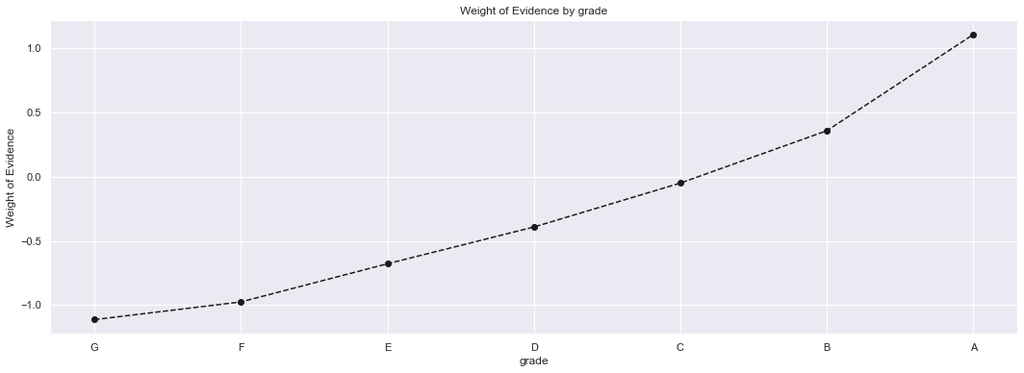

```python
# We execute the function we defined with the necessary arguments: a dataframe.
# We omit the number argument, which means the function will use its default value, 0.
plot_by_woe(df_temp)
```

### Preprocessing Discrete Variables: Creating Dummy Variables, Part 1

```python
## Now let's look at the 'home_ownership' variable
# Tabulating 'home_ownership'
df_inputs_prepr['home_ownership'].value_counts()
#df_inputs_prepr.groupby(df_inputs_prepr['home_ownership']).count()
```

```
MORTGAGE    188956
RENT        150599
OWN          33295
OTHER          137
NONE            40
ANY              1
Name: home_ownership, dtype: int64
```

```python
# We calculate weight of evidence.
df_temp = woe_discrete(df_inputs_prepr, 'home_ownership', df_targets_prepr)
df_temp
```

|  | home_ownership | n_obs | prop_good | prop_n_obs | n_good | n_bad | prop_n_good | prop_n_bad | WoE | diff_prop_good | diff_WoE | IV |
| --- | --- | --- | --- | --- | --- | --- | --- | --- | --- | --- | --- | --- |
| 0 | OTHER | 137 | 0.795620 | 0.000367 | 109.0 | 28.0 | 0.000328 | 0.000687 | -0.738602 | NaN | NaN | inf |
| 1 | NONE | 40 | 0.850000 | 0.000107 | 34.0 | 6.0 | 0.000102 | 0.000147 | -0.363144 | 0.054380 | 0.375458 | inf |
| 2 | RENT | 150599 | 0.873870 | 0.403720 | 131604.0 | 18995.0 | 0.396099 | 0.465815 | -0.162123 | 0.023870 | 0.201021 | inf |
| 3 | OWN | 33295 | 0.892536 | 0.089256 | 29717.0 | 3578.0 | 0.089442 | 0.087743 | 0.019170 | 0.018666 | 0.181294 | inf |
| 4 | MORTGAGE | 188956 | 0.903835 | 0.506546 | 170785.0 | 18171.0 | 0.514026 | 0.445608 | 0.142834 | 0.011298 | 0.123663 | inf |
| 5 | ANY | 1 | 1.000000 | 0.000003 | 1.0 | 0.0 | 0.000003 | 0.000000 | inf | 0.096165 | inf | inf |

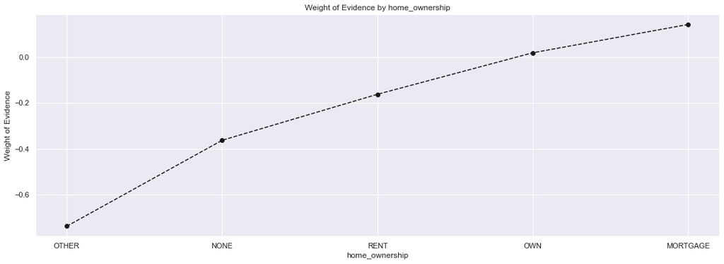

```python
# We plot the weight of evidence values.
plot_by_woe(df_temp)
```

```python
# There are many categories with very few observations and many categories with very different "good" %.
# Therefore, we create a new discrete variable where we combine some of the categories.
# 'OTHERS' and 'NONE' are riskiest but are very few.
# 'RENT' is the next riskiest.
# 'ANY' are least risky but are too few. Conceptually, they belong to the same category. Also, their inclusion would not change anything.
# We combine them in one category, 'RENT_OTHER_NONE_ANY'.
# We end up with 3 categories: 'RENT_OTHER_NONE_ANY', 'OWN', 'MORTGAGE'.
df_inputs_prepr['home_ownership:RENT_OTHER_NONE_ANY'] = sum([df_inputs_prepr['home_ownership:RENT'], df_inputs_prepr['home_ownership:OTHER'],
                                                      df_inputs_prepr['home_ownership:NONE'], df_inputs_prepr['home_ownership:ANY']])
# 'RENT_OTHER_NONE_ANY' will be the reference category.

# Alternatively:
#loan_data.loc['home_ownership' in ['RENT', 'OTHER', 'NONE', 'ANY'], 'home_ownership:RENT_OTHER_NONE_ANY'] = 1
#loan_data.loc['home_ownership' not in ['RENT', 'OTHER', 'NONE', 'ANY'], 'home_ownership:RENT_OTHER_NONE_ANY'] = 0
#loan_data.loc['loan_status' not in ['OWN'], 'home_ownership:OWN'] = 1
#loan_data.loc['loan_status' not in ['OWN'], 'home_ownership:OWN'] = 0
#loan_data.loc['loan_status' not in ['MORTGAGE'], 'home_ownership:MORTGAGE'] = 1
#loan_data.loc['loan_status' not in ['MORTGAGE'], 'home_ownership:MORTGAGE'] = 0
```

```python
# We re-calculate weight of evidence.
df_temp = woe_discrete(df_inputs_prepr, 'home_ownership:RENT_OTHER_NONE_ANY', df_targets_prepr)
df_temp
```

|  | home_ownership:RENT_OTHER_NONE_ANY | n_obs | prop_good | prop_n_obs | n_good | n_bad | prop_n_good | prop_n_bad | WoE | diff_prop_good | diff_WoE | IV |
| --- | --- | --- | --- | --- | --- | --- | --- | --- | --- | --- | --- | --- |
| 0 | 1 | 150777 | 0.873794 | 0.404198 | 131748.0 | 19029.0 | 0.396533 | 0.466649 | -0.162818 | NaN | NaN | 0.020076 |
| 1 | 0 | 222251 | 0.902142 | 0.595802 | 200502.0 | 21749.0 | 0.603467 | 0.533351 | 0.123511 | 0.028348 | 0.28633 | 0.020076 |

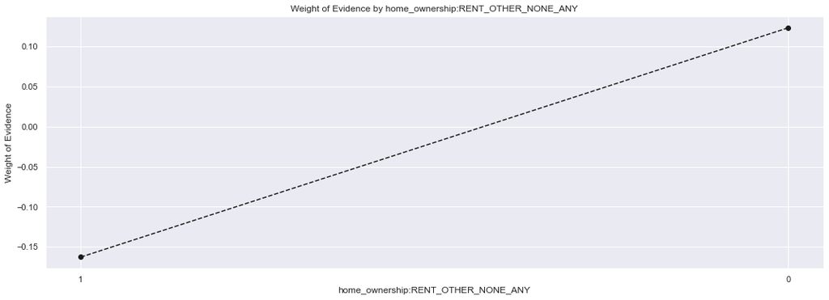

```python
# We plot the weight of evidence values.
plot_by_woe(df_temp)
```

### Preprocessing Discrete Variables: Creating Dummy Variables, Part 2

```python
## Looking at 'addr_state'
df_inputs_prepr['addr_state'].unique()
```

```
array(['SC', 'NJ', 'GA', 'MA', 'CA', 'IL', 'NC', 'NY', 'TX', 'CT', 'FL',
       'VA', 'UT', 'AZ', 'MD', 'WI', 'MI', 'CO', 'TN', 'IN', 'AL', 'NV',
       'MT', 'RI', 'OR', 'MN', 'KS', 'AK', 'PA', 'OH', 'WA', 'KY', 'OK',
       'MO', 'NM', 'HI', 'WV', 'LA', 'VT', 'AR', 'DC', 'SD', 'NH', 'WY',
       'MS', 'DE', 'IA', 'NE', 'ID', 'ME'], dtype=object)
```

```python
# We calculate weight of evidence.
df_temp = woe_discrete(df_inputs_prepr, 'addr_state', df_targets_prepr)
df_temp
```

|  | addr_state | n_obs | prop_good | prop_n_obs | n_good | n_bad | prop_n_good | prop_n_bad | WoE | diff_prop_good | diff_WoE | IV |
| --- | --- | --- | --- | --- | --- | --- | --- | --- | --- | --- | --- | --- |
| 0 | NE | 13 | 0.461538 | 0.000035 | 6.0 | 7.0 | 0.000018 | 0.000172 | -2.251896 | NaN | NaN | inf |
| 1 | IA | 13 | 0.769231 | 0.000035 | 10.0 | 3.0 | 0.000030 | 0.000074 | -0.893772 | 0.307692 | 1.358123 | inf |
| 2 | NV | 5221 | 0.864585 | 0.013996 | 4514.0 | 707.0 | 0.013586 | 0.017338 | -0.243837 | 0.095355 | 0.649935 | inf |
| 3 | FL | 25211 | 0.875808 | 0.067585 | 22080.0 | 3131.0 | 0.066456 | 0.076782 | -0.144425 | 0.011223 | 0.099411 | inf |
| 4 | HI | 2001 | 0.877061 | 0.005364 | 1755.0 | 246.0 | 0.005282 | 0.006033 | -0.132852 | 0.001253 | 0.011573 | inf |
| 5 | AL | 4671 | 0.877328 | 0.012522 | 4098.0 | 573.0 | 0.012334 | 0.014052 | -0.130376 | 0.000267 | 0.002476 | inf |
| 6 | NM | 2075 | 0.883373 | 0.005563 | 1833.0 | 242.0 | 0.005517 | 0.005935 | -0.072973 | 0.006045 | 0.057403 | inf |
| 7 | VA | 11366 | 0.883864 | 0.030470 | 10046.0 | 1320.0 | 0.030236 | 0.032370 | -0.068202 | 0.000491 | 0.004771 | inf |
| 8 | NY | 32211 | 0.883984 | 0.086350 | 28474.0 | 3737.0 | 0.085701 | 0.091643 | -0.067037 | 0.000120 | 0.001165 | inf |
| 9 | OK | 3284 | 0.884287 | 0.008804 | 2904.0 | 380.0 | 0.008740 | 0.009319 | -0.064072 | 0.000304 | 0.002965 | inf |
| 10 | TN | 4845 | 0.884623 | 0.012988 | 4286.0 | 559.0 | 0.012900 | 0.013708 | -0.060785 | 0.000336 | 0.003287 | inf |
| 11 | MO | 6017 | 0.884660 | 0.016130 | 5323.0 | 694.0 | 0.016021 | 0.017019 | -0.060425 | 0.000037 | 0.000361 | inf |
| 12 | LA | 4359 | 0.885295 | 0.011685 | 3859.0 | 500.0 | 0.011615 | 0.012262 | -0.054190 | 0.000635 | 0.006235 | inf |
| 13 | MD | 8771 | 0.885418 | 0.023513 | 7766.0 | 1005.0 | 0.023374 | 0.024646 | -0.052977 | 0.000123 | 0.001212 | inf |
| 14 | NC | 10204 | 0.885633 | 0.027355 | 9037.0 | 1167.0 | 0.027199 | 0.028618 | -0.050854 | 0.000215 | 0.002123 | inf |
| 15 | CA | 57199 | 0.885645 | 0.153337 | 50658.0 | 6541.0 | 0.152470 | 0.160405 | -0.050738 | 0.000012 | 0.000116 | inf |
| 16 | UT | 2756 | 0.887155 | 0.007388 | 2445.0 | 311.0 | 0.007359 | 0.007627 | -0.035737 | 0.001510 | 0.015000 | inf |
| 17 | KY | 3587 | 0.887650 | 0.009616 | 3184.0 | 403.0 | 0.009583 | 0.009883 | -0.030788 | 0.000495 | 0.004949 | inf |
| 18 | AZ | 8645 | 0.888259 | 0.023175 | 7679.0 | 966.0 | 0.023112 | 0.023689 | -0.024664 | 0.000609 | 0.006124 | inf |
| 19 | NJ | 14385 | 0.888286 | 0.038563 | 12778.0 | 1607.0 | 0.038459 | 0.039409 | -0.024389 | 0.000027 | 0.000275 | inf |
| 20 | AR | 2760 | 0.889855 | 0.007399 | 2456.0 | 304.0 | 0.007392 | 0.007455 | -0.008483 | 0.001569 | 0.015906 | inf |
| 21 | MI | 9191 | 0.890436 | 0.024639 | 8184.0 | 1007.0 | 0.024632 | 0.024695 | -0.002540 | 0.000581 | 0.005944 | inf |
| 22 | PA | 13090 | 0.890451 | 0.035091 | 11656.0 | 1434.0 | 0.035082 | 0.035166 | -0.002392 | 0.000014 | 0.000148 | inf |
| 23 | OH | 12135 | 0.890894 | 0.032531 | 10811.0 | 1324.0 | 0.032539 | 0.032468 | 0.002162 | 0.000443 | 0.004553 | inf |
| 24 | MN | 6526 | 0.891358 | 0.017495 | 5817.0 | 709.0 | 0.017508 | 0.017387 | 0.006939 | 0.000464 | 0.004778 | inf |
| 25 | RI | 1647 | 0.893139 | 0.004415 | 1471.0 | 176.0 | 0.004427 | 0.004316 | 0.025469 | 0.001781 | 0.018529 | inf |
| 26 | MA | 8858 | 0.893543 | 0.023746 | 7915.0 | 943.0 | 0.023822 | 0.023125 | 0.029704 | 0.000404 | 0.004235 | inf |
| 27 | DE | 1064 | 0.893797 | 0.002852 | 951.0 | 113.0 | 0.002862 | 0.002771 | 0.032381 | 0.000254 | 0.002678 | inf |
| 28 | SD | 801 | 0.893883 | 0.002147 | 716.0 | 85.0 | 0.002155 | 0.002084 | 0.033284 | 0.000086 | 0.000903 | inf |
| 29 | IN | 5210 | 0.894050 | 0.013967 | 4658.0 | 552.0 | 0.014020 | 0.013537 | 0.035048 | 0.000167 | 0.001764 | inf |
| 30 | GA | 11960 | 0.896990 | 0.032062 | 10728.0 | 1232.0 | 0.032289 | 0.030212 | 0.066473 | 0.002940 | 0.031425 | inf |
| 31 | WA | 8372 | 0.897157 | 0.022443 | 7511.0 | 861.0 | 0.022606 | 0.021114 | 0.068284 | 0.000167 | 0.001811 | inf |
| 32 | OR | 4814 | 0.897590 | 0.012905 | 4321.0 | 493.0 | 0.013005 | 0.012090 | 0.072988 | 0.000433 | 0.004704 | inf |
| 33 | WI | 4740 | 0.899789 | 0.012707 | 4265.0 | 475.0 | 0.012837 | 0.011648 | 0.097138 | 0.002199 | 0.024150 | inf |
| 34 | MT | 1103 | 0.901179 | 0.002957 | 994.0 | 109.0 | 0.002992 | 0.002673 | 0.112644 | 0.001390 | 0.015507 | inf |
| 35 | TX | 29158 | 0.903800 | 0.078166 | 26353.0 | 2805.0 | 0.079317 | 0.068787 | 0.142434 | 0.002621 | 0.029789 | inf |
| 36 | IL | 14833 | 0.904874 | 0.039764 | 13422.0 | 1411.0 | 0.040397 | 0.034602 | 0.154852 | 0.001074 | 0.012418 | inf |
| 37 | CT | 5775 | 0.905455 | 0.015481 | 5229.0 | 546.0 | 0.015738 | 0.013390 | 0.161611 | 0.000580 | 0.006760 | inf |
| 38 | KS | 3360 | 0.908036 | 0.009007 | 3051.0 | 309.0 | 0.009183 | 0.007578 | 0.192138 | 0.002581 | 0.030527 | inf |
| 39 | SC | 4448 | 0.909173 | 0.011924 | 4044.0 | 404.0 | 0.012172 | 0.009907 | 0.205830 | 0.001137 | 0.013691 | inf |
| 40 | CO | 7823 | 0.909242 | 0.020972 | 7113.0 | 710.0 | 0.021409 | 0.017411 | 0.206669 | 0.000069 | 0.000840 | inf |
| 41 | VT | 727 | 0.910591 | 0.001949 | 662.0 | 65.0 | 0.001992 | 0.001594 | 0.223133 | 0.001349 | 0.016464 | inf |
| 42 | AK | 1003 | 0.911266 | 0.002689 | 914.0 | 89.0 | 0.002751 | 0.002183 | 0.231449 | 0.000675 | 0.008316 | inf |
| 43 | MS | 980 | 0.912245 | 0.002627 | 894.0 | 86.0 | 0.002691 | 0.002109 | 0.243614 | 0.000979 | 0.012164 | inf |
| 44 | WV | 1926 | 0.920042 | 0.005163 | 1772.0 | 154.0 | 0.005333 | 0.003777 | 0.345167 | 0.007797 | 0.101553 | inf |
| 45 | NH | 1830 | 0.921858 | 0.004906 | 1687.0 | 143.0 | 0.005078 | 0.003507 | 0.370117 | 0.001816 | 0.024951 | inf |
| 46 | WY | 919 | 0.928183 | 0.002464 | 853.0 | 66.0 | 0.002567 | 0.001619 | 0.461360 | 0.006325 | 0.091242 | inf |
| 47 | DC | 1129 | 0.934455 | 0.003027 | 1055.0 | 74.0 | 0.003175 | 0.001815 | 0.559486 | 0.006272 | 0.098126 | inf |
| 48 | ME | 2 | 1.000000 | 0.000005 | 2.0 | 0.0 | 0.000006 | 0.000000 | inf | 0.065545 | inf | inf |
| 49 | ID | 10 | 1.000000 | 0.000027 | 10.0 | 0.0 | 0.000030 | 0.000000 | inf | 0.000000 | NaN | inf |

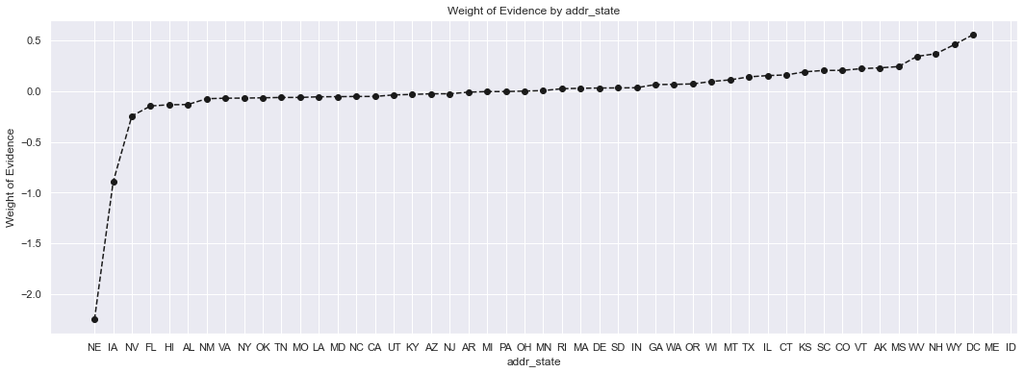

```python
# We plot the weight of evidence values.
plot_by_woe(df_temp)
```

```python
if ['addr_state:ND'] in df_inputs_prepr.columns.values:
    pass
else:
    df_inputs_prepr['addr_state:ND'] = 0
```

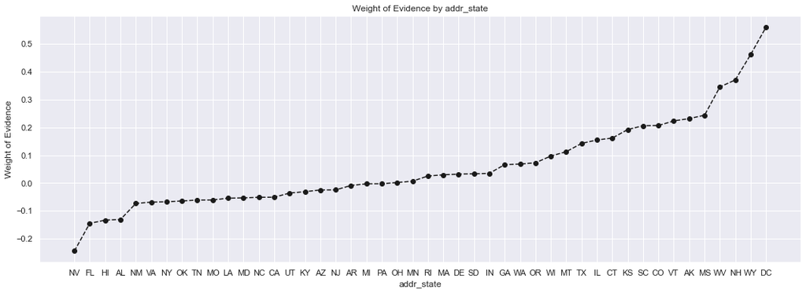

```python
# We plot the weight of evidence values.
plot_by_woe(df_temp.iloc[2: -2, : ])
```

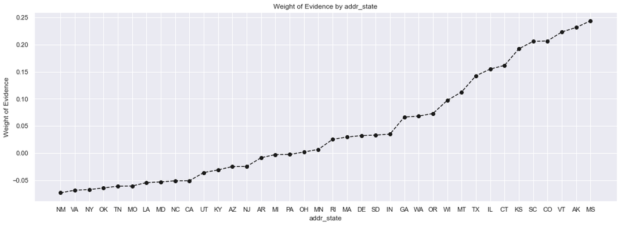

```python
# We plot the weight of evidence values.
plot_by_woe(df_temp.iloc[6: -6, : ])
```

```python
# We create the following categories:
# 'ND' 'NE' 'IA' NV' 'FL' 'HI' 'AL'
# 'NM' 'VA'
# 'NY'
# 'OK' 'TN' 'MO' 'LA' 'MD' 'NC'
# 'CA'
# 'UT' 'KY' 'AZ' 'NJ'
# 'AR' 'MI' 'PA' 'OH' 'MN'
# 'RI' 'MA' 'DE' 'SD' 'IN'
# 'GA' 'WA' 'OR'
# 'WI' 'MT'
# 'TX'
# 'IL' 'CT'
# 'KS' 'SC' 'CO' 'VT' 'AK' 'MS'
# 'WV' 'NH' 'WY' 'DC' 'ME' 'ID'

# 'IA_NV_HI_ID_AL_FL' will be the reference category.

df_inputs_prepr['addr_state:ND_NE_IA_NV_FL_HI_AL'] = sum([df_inputs_prepr['addr_state:ND'], df_inputs_prepr['addr_state:NE'],
                                              df_inputs_prepr['addr_state:IA'], df_inputs_prepr['addr_state:NV'],
                                              df_inputs_prepr['addr_state:FL'], df_inputs_prepr['addr_state:HI'],
                                                          df_inputs_prepr['addr_state:AL']])

df_inputs_prepr['addr_state:NM_VA'] = sum([df_inputs_prepr['addr_state:NM'], df_inputs_prepr['addr_state:VA']])

df_inputs_prepr['addr_state:OK_TN_MO_LA_MD_NC'] = sum([df_inputs_prepr['addr_state:OK'], df_inputs_prepr['addr_state:TN'],
                                              df_inputs_prepr['addr_state:MO'], df_inputs_prepr['addr_state:LA'],
                                              df_inputs_prepr['addr_state:MD'], df_inputs_prepr['addr_state:NC']])

df_inputs_prepr['addr_state:UT_KY_AZ_NJ'] = sum([df_inputs_prepr['addr_state:UT'], df_inputs_prepr['addr_state:KY'],
                                              df_inputs_prepr['addr_state:AZ'], df_inputs_prepr['addr_state:NJ']])

df_inputs_prepr['addr_state:AR_MI_PA_OH_MN'] = sum([df_inputs_prepr['addr_state:AR'], df_inputs_prepr['addr_state:MI'],
                                              df_inputs_prepr['addr_state:PA'], df_inputs_prepr['addr_state:OH'],
                                              df_inputs_prepr['addr_state:MN']])

df_inputs_prepr['addr_state:RI_MA_DE_SD_IN'] = sum([df_inputs_prepr['addr_state:RI'], df_inputs_prepr['addr_state:MA'],
                                              df_inputs_prepr['addr_state:DE'], df_inputs_prepr['addr_state:SD'],
                                              df_inputs_prepr['addr_state:IN']])

df_inputs_prepr['addr_state:GA_WA_OR'] = sum([df_inputs_prepr['addr_state:GA'], df_inputs_prepr['addr_state:WA'],
                                              df_inputs_prepr['addr_state:OR']])

df_inputs_prepr['addr_state:WI_MT'] = sum([df_inputs_prepr['addr_state:WI'], df_inputs_prepr['addr_state:MT']])

df_inputs_prepr['addr_state:IL_CT'] = sum([df_inputs_prepr['addr_state:IL'], df_inputs_prepr['addr_state:CT']])

df_inputs_prepr['addr_state:KS_SC_CO_VT_AK_MS'] = sum([df_inputs_prepr['addr_state:KS'], df_inputs_prepr['addr_state:SC'],
                                              df_inputs_prepr['addr_state:CO'], df_inputs_prepr['addr_state:VT'],
                                              df_inputs_prepr['addr_state:AK'], df_inputs_prepr['addr_state:MS']])

df_inputs_prepr['addr_state:WV_NH_WY_DC_ME_ID'] = sum([df_inputs_prepr['addr_state:WV'], df_inputs_prepr['addr_state:NH'],
                                              df_inputs_prepr['addr_state:WY'], df_inputs_prepr['addr_state:DC'],
                                              df_inputs_prepr['addr_state:ME'], df_inputs_prepr['addr_state:ID']])
```

### Preprocessing Discrete Variables (Continued)

```python
## looking at 'verification_status'
df_temp = woe_discrete(df_inputs_prepr, 'verification_status', df_targets_prepr)
# We calculate weight of evidence.
df_temp
```

|  | verification_status | n_obs | prop_good | prop_n_obs | n_good | n_bad | prop_n_good | prop_n_bad | WoE | diff_prop_good | diff_WoE | IV |
| --- | --- | --- | --- | --- | --- | --- | --- | --- | --- | --- | --- | --- |
| 0 | Verified | 134414 | 0.872781 | 0.360332 | 117314.0 | 17100.0 | 0.353090 | 0.419344 | -0.171969 | NaN | NaN | 0.020384 |
| 1 | Source Verified | 120030 | 0.895918 | 0.321772 | 107537.0 | 12493.0 | 0.323663 | 0.306366 | 0.054922 | 0.023137 | 0.226891 | 0.020384 |
| 2 | Not Verified | 118584 | 0.905679 | 0.317896 | 107399.0 | 11185.0 | 0.323248 | 0.274290 | 0.164232 | 0.009761 | 0.109311 | 0.020384 |

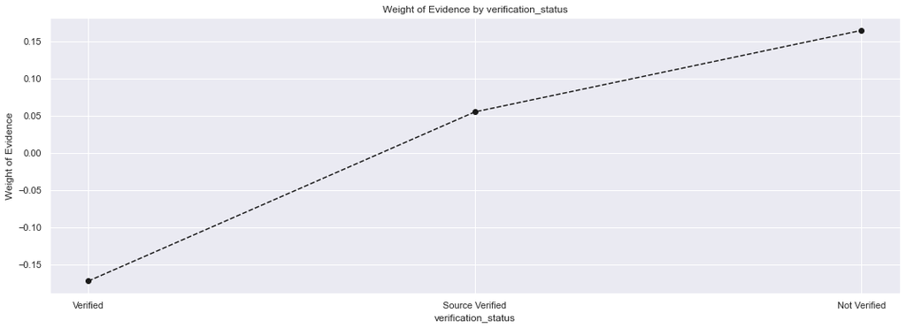

```python
# We plot the weight of evidence values.
plot_by_woe(df_temp)
```

```python
## Looking at 'purpose'
# We calculate weight of evidence
df_temp = woe_discrete(df_inputs_prepr, 'purpose', df_targets_prepr)
df_temp
```

|  | purpose | n_obs | prop_good | prop_n_obs | n_good | n_bad | prop_n_good | prop_n_bad | WoE | diff_prop_good | diff_WoE | IV |
| --- | --- | --- | --- | --- | --- | --- | --- | --- | --- | --- | --- | --- |
| 0 | small_business | 5582 | 0.786098 | 0.014964 | 4388.0 | 1194.0 | 0.013207 | 0.029280 | -0.796180 | NaN | NaN | 0.035418 |
| 1 | educational | 333 | 0.801802 | 0.000893 | 267.0 | 66.0 | 0.000804 | 0.001619 | -0.700151 | 0.015704 | 0.096029 | 0.035418 |
| 2 | moving | 2392 | 0.839465 | 0.006412 | 2008.0 | 384.0 | 0.006044 | 0.009417 | -0.443493 | 0.037663 | 0.256658 | 0.035418 |
| 3 | house | 1830 | 0.860109 | 0.004906 | 1574.0 | 256.0 | 0.004737 | 0.006278 | -0.281547 | 0.020644 | 0.161946 | 0.035418 |
| 4 | other | 18884 | 0.862264 | 0.050624 | 16283.0 | 2601.0 | 0.049008 | 0.063784 | -0.263519 | 0.002155 | 0.018028 | 0.035418 |
| 5 | renewable_energy | 281 | 0.864769 | 0.000753 | 243.0 | 38.0 | 0.000731 | 0.000932 | -0.242270 | 0.002504 | 0.021250 | 0.035418 |
| 6 | medical | 3684 | 0.868350 | 0.009876 | 3199.0 | 485.0 | 0.009628 | 0.011894 | -0.211300 | 0.003581 | 0.030969 | 0.035418 |
| 7 | wedding | 1887 | 0.881823 | 0.005059 | 1664.0 | 223.0 | 0.005008 | 0.005469 | -0.087937 | 0.013473 | 0.123363 | 0.035418 |
| 8 | vacation | 1991 | 0.882471 | 0.005337 | 1757.0 | 234.0 | 0.005288 | 0.005738 | -0.081703 | 0.000648 | 0.006234 | 0.035418 |
| 9 | debt_consolidation | 219183 | 0.886884 | 0.587578 | 194390.0 | 24793.0 | 0.585071 | 0.607999 | -0.038440 | 0.004413 | 0.043263 | 0.035418 |
| 10 | home_improvement | 21238 | 0.900697 | 0.056934 | 19129.0 | 2109.0 | 0.057574 | 0.051719 | 0.107247 | 0.013812 | 0.145687 | 0.035418 |
| 11 | major_purchase | 7837 | 0.905449 | 0.021009 | 7096.0 | 741.0 | 0.021357 | 0.018172 | 0.161541 | 0.004752 | 0.054294 | 0.035418 |
| 12 | car | 4325 | 0.909595 | 0.011594 | 3934.0 | 391.0 | 0.011840 | 0.009589 | 0.210959 | 0.004147 | 0.049419 | 0.035418 |
| 13 | credit_card | 83581 | 0.913102 | 0.224061 | 76318.0 | 7263.0 | 0.229701 | 0.178111 | 0.254371 | 0.003507 | 0.043411 | 0.035418 |

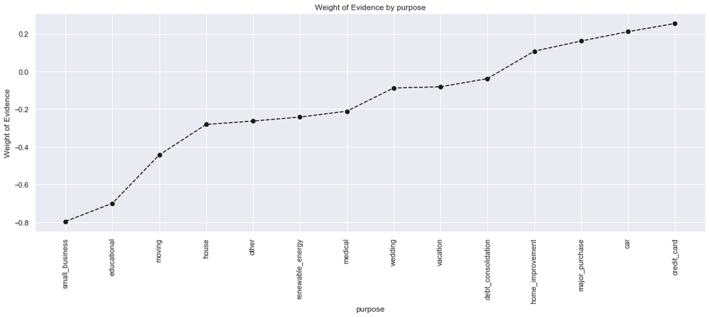

```python
# We plot the weight of evidence values.
plot_by_woe(df_temp, 90)
```

```python
# We combine 'educational', 'small_business', 'wedding', 'renewable_energy', 'moving', 'house' in one category: 'educ__sm_b__wedd__ren_en__mov__house'.
# We combine 'other', 'medical', 'vacation' in one category: 'oth__med__vacation'.
# We combine 'major_purchase', 'car', 'home_improvement' in one category: 'major_purch__car__home_impr'.
# We leave 'debt_consolidtion' in a separate category.
# We leave 'credit_card' in a separate category.
# 'educ__sm_b__wedd__ren_en__mov__house' will be the reference category.
df_inputs_prepr['purpose:educ__sm_b__wedd__ren_en__mov__house'] = sum([df_inputs_prepr['purpose:educational'], df_inputs_prepr['purpose:small_business'],
                                                                 df_inputs_prepr['purpose:wedding'], df_inputs_prepr['purpose:renewable_energy'],
                                                                 df_inputs_prepr['purpose:moving'], df_inputs_prepr['purpose:house']])
df_inputs_prepr['purpose:oth__med__vacation'] = sum([df_inputs_prepr['purpose:other'], df_inputs_prepr['purpose:medical'],
                                             df_inputs_prepr['purpose:vacation']])
df_inputs_prepr['purpose:major_purch__car__home_impr'] = sum([df_inputs_prepr['purpose:major_purchase'], df_inputs_prepr['purpose:car'],
                                                        df_inputs_prepr['purpose:home_improvement']])
```

```python
## Looking at 'initial_list_status'
df_temp = woe_discrete(df_inputs_prepr, 'initial_list_status', df_targets_prepr)
df_temp
```

|  | initial_list_status | n_obs | prop_good | prop_n_obs | n_good | n_bad | prop_n_good | prop_n_bad | WoE | diff_prop_good | diff_WoE | IV |
| --- | --- | --- | --- | --- | --- | --- | --- | --- | --- | --- | --- | --- |
| 0 | f | 242514 | 0.879694 | 0.650123 | 213338.0 | 29176.0 | 0.642101 | 0.715484 | -0.108214 | NaN | NaN | 0.02478 |
| 1 | w | 130514 | 0.911105 | 0.349877 | 118912.0 | 11602.0 | 0.357899 | 0.284516 | 0.229461 | 0.031412 | 0.337675 | 0.02478 |

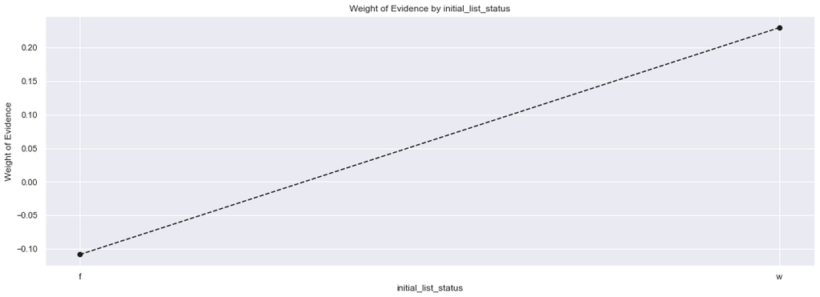

```python
# We plot the weight of evidence values.
plot_by_woe(df_temp)
```

#### 2.3.4. Preprocessing Continuous Variables: Automating Calculations and Visualizing Results

```python
## WoE function for ordered discrete and continuous variables
# Here we define a function similar to the one above, ...
# ... with one slight difference: we order the results by the values of a different column.
# The function takes 3 arguments: a DataFrame, a string, and a DataFrame. The function returns a DataDrame as a result.
def woe_ordered_continuous(df, discrete_variabe_name, good_bad_variable_df):
    df = pd.concat([df[discrete_variabe_name], good_bad_variable_df], axis = 1)
    df = pd.concat([df.groupby(df.columns.values[0], as_index = False)[df.columns.values[1]].count(),
                    df.groupby(df.columns.values[0], as_index = False)[df.columns.values[1]].mean()], axis = 1)
    df = df.iloc[:, [0, 1, 3]]
    df.columns = [df.columns.values[0], 'n_obs', 'prop_good']
    df['prop_n_obs'] = df['n_obs'] / df['n_obs'].sum()
    df['n_good'] = df['prop_good'] * df['n_obs']
    df['n_bad'] = (1 - df['prop_good']) * df['n_obs']
    df['prop_n_good'] = df['n_good'] / df['n_good'].sum()
    df['prop_n_bad'] = df['n_bad'] / df['n_bad'].sum()
    df['WoE'] = np.log(df['prop_n_good'] / df['prop_n_bad'])
    #df = df.sort_values(['WoE'])
    #df = df.reset_index(drop = True)
    df['diff_prop_good'] = df['prop_good'].diff().abs()
    df['diff_WoE'] = df['WoE'].diff().abs()
    df['IV'] = (df['prop_n_good'] - df['prop_n_bad']) * df['WoE']
    df['IV'] = df['IV'].sum()
    return df
```

#### 2.3.4.1. Preprocessing Continuous Variables: Creating Dummy Variables, Part 1

```python
df_inputs_prepr.describe()
```

|  | Unnamed: 0 | id | member_id | loan_amnt | funded_amnt | funded_amnt_inv | int_rate | installment | annual_inc | dti | delinq_2yrs | inq_last_6mths | mths_since_last_delinq | mths_since_last_record | open_acc | pub_rec | revol_bal | revol_util | total_acc | out_prncp | out_prncp_inv | total_pymnt | total_pymnt_inv | total_rec_prncp | total_rec_int | total_rec_late_fee | recoveries | collection_recovery_fee | last_pymnt_amnt | … |
| --- | --- | --- | --- | --- | --- | --- | --- | --- | --- | --- | --- | --- | --- | --- | --- | --- | --- | --- | --- | --- | --- | --- | --- | --- | --- | --- | --- | --- | --- | --- |
| count | 373028.000000 | 3.730280e+05 | 3.730280e+05 | 373028.000000 | 373028.000000 | 373028.000000 | 373028.000000 | 373028.000000 | 3.730280e+05 | 373028.000000 | 373028.000000 | 373028.000000 | 172843.000000 | 50067.000000 | 373028.000000 | 373028.000000 | 3.730280e+05 | 372759.000000 | 373028.000000 | 373028.000000 | 373028.000000 | 373028.000000 | 373028.000000 | 373028.000000 | 373028.000000 | 373028.000000 | 373028.000000 | 373028.000000 | 373028.000000 | … |
| mean | 233050.214038 | 1.308110e+07 | 1.459914e+07 | 14318.314778 | 14292.326514 | 14222.854516 | 13.827497 | 432.078820 | 7.322373e+04 | 17.221684 | 0.284359 | 0.804859 | 34.097424 | 74.279645 | 11.185579 | 0.160213 | 1.622348e+04 | 56.174364 | 25.061148 | 4407.610163 | 4405.984100 | 11544.760120 | 11474.035877 | 8869.176736 | 2589.195583 | 0.646525 | 85.741279 | 9.047898 | 3126.384531 | … |
| std | 134586.411795 | 1.089460e+07 | 1.168336e+07 | 8287.668197 | 8275.446272 | 8298.860851 | 4.354152 | 243.523044 | 5.368944e+04 | 7.845668 | 0.796584 | 1.093220 | 21.770321 | 30.384591 | 4.984202 | 0.509876 | 2.069231e+04 | 23.750023 | 11.599953 | 6354.286428 | 6352.388866 | 8270.221369 | 8258.597346 | 7033.591859 | 2485.288909 | 5.250436 | 555.229929 | 86.572502 | 5555.260450 | … |
| min | 0.000000 | 5.473400e+04 | 7.047300e+04 | 500.000000 | 500.000000 | 0.000000 | 5.420000 | 15.670000 | 1.896000e+03 | 0.000000 | 0.000000 | 0.000000 | 0.000000 | 0.000000 | 0.000000 | 0.000000 | 0.000000e+00 | 0.000000 | 0.000000 | 0.000000 | 0.000000 | 0.000000 | 0.000000 | 0.000000 | 0.000000 | 0.000000 | 0.000000 | 0.000000 | 0.000000 | … |
| 25% | 116448.750000 | 3.639984e+06 | 4.379781e+06 | 8000.000000 | 8000.000000 | 8000.000000 | 10.990000 | 256.480000 | 4.500000e+04 | 11.370000 | 0.000000 | 0.000000 | 16.000000 | 53.000000 | 8.000000 | 0.000000 | 6.410750e+03 | 39.200000 | 17.000000 | 0.000000 | 0.000000 | 5557.825000 | 5501.140000 | 3712.160000 | 957.017500 | 0.000000 | 0.000000 | 0.000000 | 312.610000 | … |
| 50% | 233085.500000 | 1.010677e+07 | 1.194003e+07 | 12000.000000 | 12000.000000 | 12000.000000 | 13.660000 | 379.890000 | 6.289300e+04 | 16.880000 | 0.000000 | 0.000000 | 31.000000 | 76.000000 | 10.000000 | 0.000000 | 1.175700e+04 | 57.600000 | 23.000000 | 430.305000 | 429.950000 | 9421.340000 | 9358.200000 | 6827.070000 | 1819.175000 | 0.000000 | 0.000000 | 0.000000 | 545.960000 | … |
| 75% | 349508.250000 | 2.073958e+07 | 2.300367e+07 | 20000.000000 | 20000.000000 | 19950.000000 | 16.490000 | 566.332500 | 8.880000e+04 | 22.780000 | 0.000000 | 1.000000 | 49.000000 | 102.000000 | 14.000000 | 0.000000 | 2.034400e+04 | 74.700000 | 32.000000 | 7332.750000 | 7331.950000 | 15309.364747 | 15234.230000 | 12000.000000 | 3305.430000 | 0.000000 | 0.000000 | 0.000000 | 3206.312500 | … |
| max | 466283.000000 | 3.809811e+07 | 4.086083e+07 | 35000.000000 | 35000.000000 | 35000.000000 | 26.060000 | 1409.990000 | 7.141778e+06 | 39.990000 | 29.000000 | 33.000000 | 188.000000 | 121.000000 | 84.000000 | 63.000000 | 2.568995e+06 | 892.300000 | 150.000000 | 32160.380000 | 32160.380000 | 57777.579870 | 57777.580000 | 35000.030000 | 24205.620000 | 358.680000 | 33520.270000 | 7002.190000 | 36234.440000 | … |

```python
## Looking at 'term_int'
df_inputs_prepr['term_int'].unique()
# There are only two unique values, 36 and 60.
```

```
array([36, 60], dtype=int64)
```

```python
df_temp = woe_ordered_continuous(df_inputs_prepr, 'term_int', df_targets_prepr)
# We calculate weight of evidence.
df_temp
```

|  | term_int | n_obs | prop_good | prop_n_obs | n_good | n_bad | prop_n_good | prop_n_bad | WoE | diff_prop_good | diff_WoE | IV |
| --- | --- | --- | --- | --- | --- | --- | --- | --- | --- | --- | --- | --- |
| 0 | 36 | 270419 | 0.902995 | 0.724929 | 244187.0 | 26232.0 | 0.73495 | 0.643288 | 0.133209 | NaN | NaN | 0.039434 |
| 1 | 60 | 102609 | 0.858239 | 0.275071 | 88063.0 | 14546.0 | 0.26505 | 0.356712 | -0.297009 | 0.044756 | 0.430218 | 0.039434 |

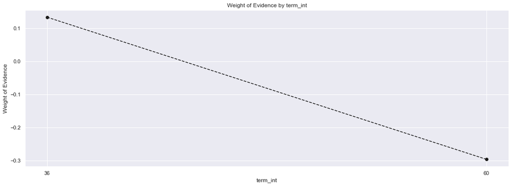

```python
plot_by_woe(df_temp)
# We plot the weight of evidence values.
```

```python
# Leave as is.
# '60' will be the reference category.
df_inputs_prepr['term:36'] = np.where((df_inputs_prepr['term_int'] == 36), 1, 0)
df_inputs_prepr['term:60'] = np.where((df_inputs_prepr['term_int'] == 60), 1, 0)
```

```python
## Looking at 'emp_length_int'
df_inputs_prepr['emp_length_int'].unique()
# Has only 11 levels: from 0 to 10. Hence, we turn it into a factor with 11 levels.
```

```
array([ 3.,  6., 10.,  7.,  5.,  0.,  2.,  9.,  1.,  8.,  4.])
```

```python
df_temp = woe_ordered_continuous(df_inputs_prepr, 'emp_length_int', df_targets_prepr)
# We calculate weight of evidence.
df_temp
```

|  | emp_length_int | n_obs | prop_good | prop_n_obs | n_good | n_bad | prop_n_good | prop_n_bad | WoE | diff_prop_good | diff_WoE | IV |
| --- | --- | --- | --- | --- | --- | --- | --- | --- | --- | --- | --- | --- |
| 0 | 0.0 | 45720 | 0.876400 | 0.122565 | 40069.0 | 5651.0 | 0.120599 | 0.138580 | -0.138975 | NaN | NaN | 0.006506 |
| 1 | 1.0 | 23654 | 0.886996 | 0.063411 | 20981.0 | 2673.0 | 0.063148 | 0.065550 | -0.037329 | 0.010596 | 0.101645 | 0.006506 |
| 2 | 2.0 | 33078 | 0.890955 | 0.088674 | 29471.0 | 3607.0 | 0.088701 | 0.088455 | 0.002785 | 0.003959 | 0.040114 | 0.006506 |
| 3 | 3.0 | 29205 | 0.890772 | 0.078292 | 26015.0 | 3190.0 | 0.078299 | 0.078228 | 0.000907 | 0.000183 | 0.001878 | 0.006506 |
| 4 | 4.0 | 22468 | 0.890644 | 0.060231 | 20011.0 | 2457.0 | 0.060229 | 0.060253 | -0.000404 | 0.000128 | 0.001311 | 0.006506 |
| 5 | 5.0 | 24602 | 0.884725 | 0.065952 | 21766.0 | 2836.0 | 0.065511 | 0.069547 | -0.059790 | 0.005920 | 0.059387 | 0.006506 |
| 6 | 6.0 | 20887 | 0.883899 | 0.055993 | 18462.0 | 2425.0 | 0.055567 | 0.059468 | -0.067862 | 0.000826 | 0.008071 | 0.006506 |
| 7 | 7.0 | 21049 | 0.887453 | 0.056427 | 18680.0 | 2369.0 | 0.056223 | 0.058095 | -0.032759 | 0.003554 | 0.035102 | 0.006506 |
| 8 | 8.0 | 17853 | 0.889878 | 0.047860 | 15887.0 | 1966.0 | 0.047816 | 0.048212 | -0.008245 | 0.002425 | 0.024515 | 0.006506 |
| 9 | 9.0 | 14267 | 0.886662 | 0.038246 | 12650.0 | 1617.0 | 0.038074 | 0.039654 | -0.040660 | 0.003217 | 0.032416 | 0.006506 |
| 10 | 10.0 | 120245 | 0.900312 | 0.322348 | 108258.0 | 11987.0 | 0.325833 | 0.293958 | 0.102950 | 0.013650 | 0.143610 | 0.006506 |

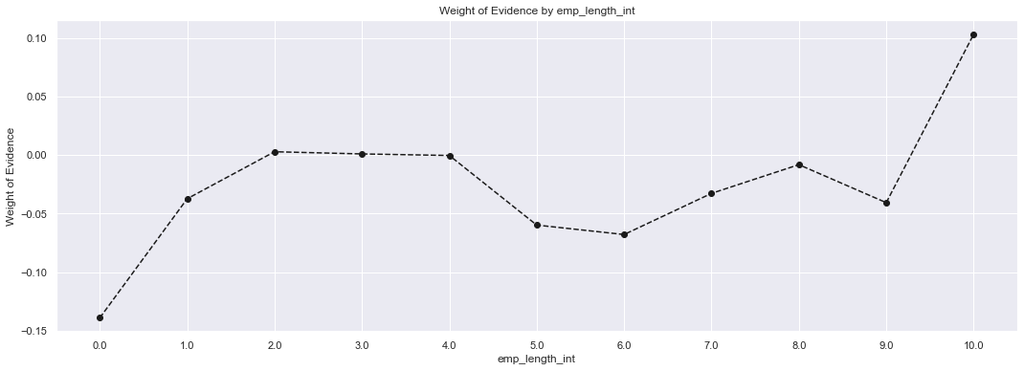

```python
# We plot the weight of evidence values.
plot_by_woe(df_temp)
```

```python
# We create the following categories: '0', '1', '2 - 4', '5 - 6', '7 - 9', '10'
# '0' will be the reference category
df_inputs_prepr['emp_length:0'] = np.where(df_inputs_prepr['emp_length_int'].isin([0]), 1, 0)
df_inputs_prepr['emp_length:1'] = np.where(df_inputs_prepr['emp_length_int'].isin([1]), 1, 0)
df_inputs_prepr['emp_length:2-4'] = np.where(df_inputs_prepr['emp_length_int'].isin(range(2, 5)), 1, 0)
df_inputs_prepr['emp_length:5-6'] = np.where(df_inputs_prepr['emp_length_int'].isin(range(5, 7)), 1, 0)
df_inputs_prepr['emp_length:7-9'] = np.where(df_inputs_prepr['emp_length_int'].isin(range(7, 10)), 1, 0)
df_inputs_prepr['emp_length:10'] = np.where(df_inputs_prepr['emp_length_int'].isin([10]), 1, 0)
```

#### 2.3.4.2. Preprocessing Continuous Variables: Creating Dummy Variables, Part 2

```python
## Looking at 'mths_since_issue_d'
df_inputs_prepr['mths_since_issue_d'].unique()
```

```
array([ 82., 101.,  91.,  81., 138.,  74., 128.,  90.,  79.,  94.,  95.,
        80.,  77.,  88.,  96., 150.,  87.,  99.,  86.,  84.,  85.,  78.,
        75., 103., 106., 124.,  83., 113., 100.,  76.,  98., 126., 102.,
        93., 116., 105.,  89.,  97., 110., 111., 107., 125., 118., 119.,
        92., 140., 120., 109., 122.,  73., 108., 129., 114., 104., 121.,
       123., 127., 153., 130., 132., 115., 112., 117., 133., 131., 135.,
       141., 162., 142., 155., 147., 156., 151., 134., 139., 143., 137.,
       159., 158., 145., 154., 157., 161., 136., 152., 149., 146., 160.,
       144., 163., 148.])
```

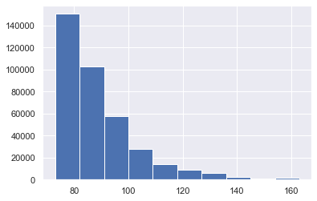

```python
# Creating a histogram of 'mths_since_issue_d'
df_inputs_prepr['mths_since_issue_d'].hist()
```

```python
# Here we do fine-classing: using the 'cut' method,
# we split the variable into 50 categories by its values.
df_inputs_prepr['mths_since_issue_d_factor'] = pd.cut(df_inputs_prepr['mths_since_issue_d'], 50)
```

```python
df_inputs_prepr['mths_since_issue_d_factor']
```

```
427211      (80.2, 82.0]
206088    (100.0, 101.8]
136020      (89.2, 91.0]
412305      (80.2, 82.0]
36159     (137.8, 139.6]
               ...
259178     (72.91, 74.8]
365838      (78.4, 80.2]
131932      (89.2, 91.0]
146867      (92.8, 94.6]
121958      (89.2, 91.0]
Name: mths_since_issue_d_factor, Length: 373028, dtype: category
Categories (50, interval[float64]): [(72.91, 74.8] < (74.8, 76.6] < (76.6, 78.4] < (78.4, 80.2] ... (155.8, 157.6] < (157.6, 159.4] < (159.4, 161.2] < (161.2, 163.0]]
```

```python
# mths_since_issue_d
df_temp = woe_ordered_continuous(df_inputs_prepr, 'mths_since_issue_d_factor', df_targets_prepr)
# We calculate weight of evidence.
df_temp
```

|  | mths_since_issue_d_factor | n_obs | prop_good | prop_n_obs | n_good | n_bad | prop_n_good | prop_n_bad | WoE | diff_prop_good | diff_WoE | IV |
| --- | --- | --- | --- | --- | --- | --- | --- | --- | --- | --- | --- | --- |
| 0 | (72.91, 74.8] | 28170 | 0.942244 | 0.075517 | 26543.0 | 1627.0 | 0.079889 | 0.039899 | 0.694283 | NaN | NaN | 0.113186 |
| 1 | (74.8, 76.6] | 39636 | 0.928424 | 0.106255 | 36799.0 | 2837.0 | 0.110757 | 0.069572 | 0.464979 | 0.013820 | 0.229305 | 0.113186 |
| 2 | (76.6, 78.4] | 38614 | 0.917284 | 0.103515 | 35420.0 | 3194.0 | 0.106606 | 0.078327 | 0.308258 | 0.011140 | 0.156721 | 0.113186 |
| 3 | (78.4, 80.2] | 29038 | 0.908603 | 0.077844 | 26384.0 | 2654.0 | 0.079410 | 0.065084 | 0.198945 | 0.008681 | 0.109313 | 0.113186 |
| 4 | (80.2, 82.0] | 28367 | 0.901787 | 0.076045 | 25581.0 | 2786.0 | 0.076993 | 0.068321 | 0.119498 | 0.006815 | 0.079447 | 0.113186 |
| 5 | (82.0, 83.8] | 12165 | 0.899301 | 0.032611 | 10940.0 | 1225.0 | 0.032927 | 0.030041 | 0.091740 | 0.002486 | 0.027758 | 0.113186 |
| 6 | (83.8, 85.6] | 24451 | 0.898900 | 0.065547 | 21979.0 | 2472.0 | 0.066152 | 0.060621 | 0.087315 | 0.000401 | 0.004425 | 0.113186 |
| 7 | (85.6, 87.4] | 22969 | 0.888328 | 0.061574 | 20404.0 | 2565.0 | 0.061412 | 0.062902 | -0.023972 | 0.010572 | 0.111287 | 0.113186 |
| 8 | (87.4, 89.2] | 20640 | 0.880523 | 0.055331 | 18174.0 | 2466.0 | 0.054700 | 0.060474 | -0.100350 | 0.007804 | 0.076378 | 0.113186 |
| 9 | (89.2, 91.0] | 18312 | 0.866863 | 0.049090 | 15874.0 | 2438.0 | 0.047777 | 0.059787 | -0.224240 | 0.013660 | 0.123890 | 0.113186 |
| 10 | (91.0, 92.8] | 8286 | 0.856746 | 0.022213 | 7099.0 | 1187.0 | 0.021366 | 0.029109 | -0.309220 | 0.010117 | 0.084980 | 0.113186 |
| 11 | (92.8, 94.6] | 14120 | 0.863031 | 0.037852 | 12186.0 | 1934.0 | 0.036677 | 0.047428 | -0.257048 | 0.006285 | 0.052173 | 0.113186 |
| 12 | (94.6, 96.4] | 11529 | 0.859658 | 0.030907 | 9911.0 | 1618.0 | 0.029830 | 0.039678 | -0.285291 | 0.003373 | 0.028243 | 0.113186 |
| 13 | (96.4, 98.2] | 9974 | 0.852817 | 0.026738 | 8506.0 | 1468.0 | 0.025601 | 0.036000 | -0.340874 | 0.006841 | 0.055584 | 0.113186 |
| 14 | (98.2, 100.0] | 9811 | 0.851901 | 0.026301 | 8358.0 | 1453.0 | 0.025156 | 0.035632 | -0.348156 | 0.000916 | 0.007282 | 0.113186 |
| 15 | (100.0, 101.8] | 4304 | 0.844331 | 0.011538 | 3634.0 | 670.0 | 0.010938 | 0.016430 | -0.406933 | 0.007570 | 0.058777 | 0.113186 |
| 16 | (101.8, 103.6] | 6723 | 0.824781 | 0.018023 | 5545.0 | 1178.0 | 0.016689 | 0.028888 | -0.548666 | 0.019550 | 0.141733 | 0.113186 |
| 17 | (103.6, 105.4] | 5334 | 0.841207 | 0.014299 | 4487.0 | 847.0 | 0.013505 | 0.020771 | -0.430506 | 0.016427 | 0.118160 | 0.113186 |
| 18 | (105.4, 107.2] | 4377 | 0.846699 | 0.011734 | 3706.0 | 671.0 | 0.011154 | 0.016455 | -0.388806 | 0.005491 | 0.041700 | 0.113186 |
| 19 | (107.2, 109.0] | 3868 | 0.827559 | 0.010369 | 3201.0 | 667.0 | 0.009634 | 0.016357 | -0.529316 | 0.019139 | 0.140511 | 0.113186 |
| 20 | (109.0, 110.8] | 1785 | 0.855462 | 0.004785 | 1527.0 | 258.0 | 0.004596 | 0.006327 | -0.319644 | 0.027903 | 0.209672 | 0.113186 |
| 21 | (110.8, 112.6] | 3395 | 0.853019 | 0.009101 | 2896.0 | 499.0 | 0.008716 | 0.012237 | -0.339265 | 0.002443 | 0.019621 | 0.113186 |
| 22 | (112.6, 114.4] | 3055 | 0.853682 | 0.008190 | 2608.0 | 447.0 | 0.007850 | 0.010962 | -0.333965 | 0.000663 | 0.005301 | 0.113186 |
| 23 | (114.4, 116.2] | 2849 | 0.842050 | 0.007637 | 2399.0 | 450.0 | 0.007220 | 0.011035 | -0.424185 | 0.011633 | 0.090221 | 0.113186 |
| 24 | (116.2, 118.0] | 2412 | 0.851990 | 0.006466 | 2055.0 | 357.0 | 0.006185 | 0.008755 | -0.347450 | 0.009940 | 0.076736 | 0.113186 |
| 25 | (118.0, 119.8] | 1044 | 0.869732 | 0.002799 | 908.0 | 136.0 | 0.002733 | 0.003335 | -0.199155 | 0.017742 | 0.148294 | 0.113186 |
| 26 | (119.8, 121.6] | 2182 | 0.870761 | 0.005849 | 1900.0 | 282.0 | 0.005719 | 0.006915 | -0.190043 | 0.001029 | 0.009113 | 0.113186 |
| 27 | (121.6, 123.4] | 1997 | 0.854782 | 0.005353 | 1707.0 | 290.0 | 0.005138 | 0.007112 | -0.325133 | 0.015979 | 0.135090 | 0.113186 |
| 28 | (123.4, 125.2] | 1921 | 0.833941 | 0.005150 | 1602.0 | 319.0 | 0.004822 | 0.007823 | -0.483928 | 0.020842 | 0.158795 | 0.113186 |
| 29 | (125.2, 127.0] | 1870 | 0.842246 | 0.005013 | 1575.0 | 295.0 | 0.004740 | 0.007234 | -0.422710 | 0.008305 | 0.061218 | 0.113186 |
| 30 | (127.0, 128.8] | 795 | 0.859119 | 0.002131 | 683.0 | 112.0 | 0.002056 | 0.002747 | -0.289749 | 0.016874 | 0.132961 | 0.113186 |
| 31 | (128.8, 130.6] | 1373 | 0.890750 | 0.003681 | 1223.0 | 150.0 | 0.003681 | 0.003678 | 0.000682 | 0.031631 | 0.290431 | 0.113186 |
| 32 | (130.6, 132.4] | 1087 | 0.874885 | 0.002914 | 951.0 | 136.0 | 0.002862 | 0.003335 | -0.152886 | 0.015865 | 0.153568 | 0.113186 |
| 33 | (132.4, 134.2] | 1044 | 0.882184 | 0.002799 | 921.0 | 123.0 | 0.002772 | 0.003016 | -0.084469 | 0.007299 | 0.068417 | 0.113186 |
| 34 | (134.2, 136.0] | 877 | 0.856328 | 0.002351 | 751.0 | 126.0 | 0.002260 | 0.003090 | -0.312621 | 0.025856 | 0.228152 | 0.113186 |
| 35 | (136.0, 137.8] | 346 | 0.878613 | 0.000928 | 304.0 | 42.0 | 0.000915 | 0.001030 | -0.118387 | 0.022284 | 0.194234 | 0.113186 |
| 36 | (137.8, 139.6] | 647 | 0.863988 | 0.001734 | 559.0 | 88.0 | 0.001682 | 0.002158 | -0.248932 | 0.014625 | 0.130545 | 0.113186 |
| 37 | (139.6, 141.4] | 542 | 0.850554 | 0.001453 | 461.0 | 81.0 | 0.001388 | 0.001986 | -0.358796 | 0.013434 | 0.109864 | 0.113186 |
| 38 | (141.4, 143.2] | 497 | 0.869215 | 0.001332 | 432.0 | 65.0 | 0.001300 | 0.001594 | -0.203707 | 0.018662 | 0.155089 | 0.113186 |
| 39 | (143.2, 145.0] | 403 | 0.853598 | 0.001080 | 344.0 | 59.0 | 0.001035 | 0.001447 | -0.334641 | 0.015617 | 0.130934 | 0.113186 |
| 40 | (145.0, 146.8] | 173 | 0.803468 | 0.000464 | 139.0 | 34.0 | 0.000418 | 0.000834 | -0.689632 | 0.050130 | 0.354991 | 0.113186 |
| 41 | (146.8, 148.6] | 139 | 0.834532 | 0.000373 | 116.0 | 23.0 | 0.000349 | 0.000564 | -0.479649 | 0.031064 | 0.209983 | 0.113186 |
| 42 | (148.6, 150.4] | 204 | 0.799020 | 0.000547 | 163.0 | 41.0 | 0.000491 | 0.001005 | -0.717567 | 0.035513 | 0.237918 | 0.113186 |
| 43 | (150.4, 152.2] | 182 | 0.796703 | 0.000488 | 145.0 | 37.0 | 0.000436 | 0.000907 | -0.731929 | 0.002316 | 0.014362 | 0.113186 |
| 44 | (152.2, 154.0] | 530 | 0.762264 | 0.001421 | 404.0 | 126.0 | 0.001216 | 0.003090 | -0.932612 | 0.034439 | 0.200683 | 0.113186 |
| 45 | (154.0, 155.8] | 247 | 0.797571 | 0.000662 | 197.0 | 50.0 | 0.000593 | 0.001226 | -0.726564 | 0.035307 | 0.206048 | 0.113186 |
| 46 | (155.8, 157.6] | 394 | 0.723350 | 0.001056 | 285.0 | 109.0 | 0.000858 | 0.002673 | -1.136604 | 0.074221 | 0.410039 | 0.113186 |
| 47 | (157.6, 159.4] | 176 | 0.704545 | 0.000472 | 124.0 | 52.0 | 0.000373 | 0.001275 | -1.228707 | 0.018805 | 0.092103 | 0.113186 |
| 48 | (159.4, 161.2] | 104 | 0.750000 | 0.000279 | 78.0 | 26.0 | 0.000235 | 0.000638 | -0.999133 | 0.045455 | 0.229574 | 0.113186 |
| 49 | (161.2, 163.0] | 70 | 0.885714 | 0.000188 | 62.0 | 8.0 | 0.000187 | 0.000196 | -0.050052 | 0.135714 | 0.949081 | 0.113186 |

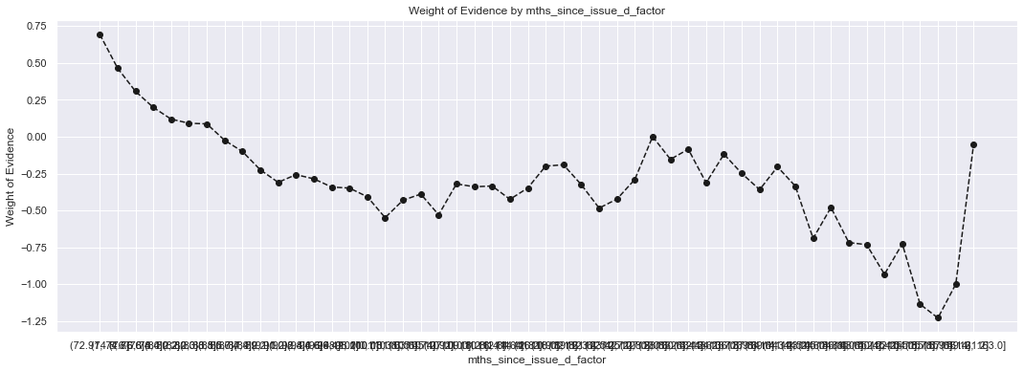

```python
plot_by_woe(df_temp)
# We plot the weight of evidence values.
# We have to rotate the labels because we cannot read them otherwise.
```

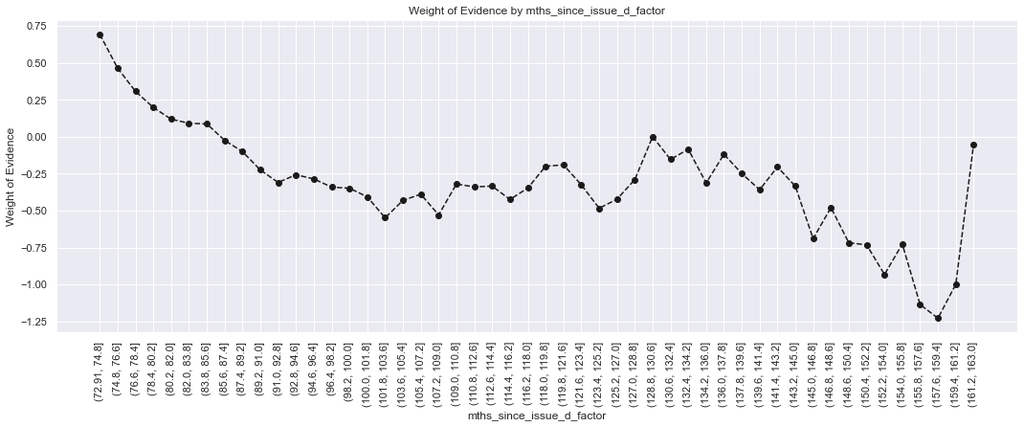

```python
# We plot the weight of evidence values, rotating the labels 90 degrees.
plot_by_woe(df_temp, 90)
```

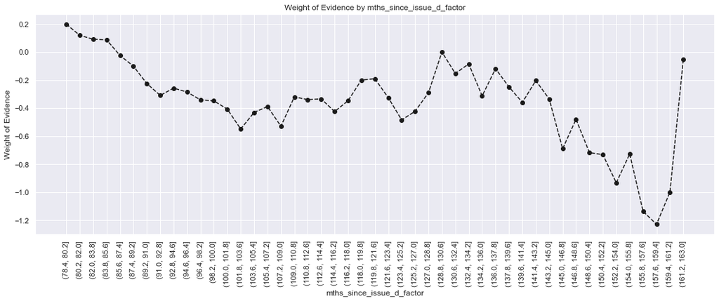

```python
# We plot the weight of evidence values.
plot_by_woe(df_temp.iloc[3: , : ], 90)
```

```python
# We create the following categories:
# < 38, 38 - 39, 40 - 41, 42 - 48, 49 - 52, 53 - 64, 65 - 84, > 84.
df_inputs_prepr['mths_since_issue_d:<38'] = np.where(df_inputs_prepr['mths_since_issue_d'].isin(range(38)), 1, 0)
df_inputs_prepr['mths_since_issue_d:38-39'] = np.where(df_inputs_prepr['mths_since_issue_d'].isin(range(38, 40)), 1, 0)
df_inputs_prepr['mths_since_issue_d:40-41'] = np.where(df_inputs_prepr['mths_since_issue_d'].isin(range(40, 42)), 1, 0)
df_inputs_prepr['mths_since_issue_d:42-48'] = np.where(df_inputs_prepr['mths_since_issue_d'].isin(range(42, 49)), 1, 0)
df_inputs_prepr['mths_since_issue_d:49-52'] = np.where(df_inputs_prepr['mths_since_issue_d'].isin(range(49, 53)), 1, 0)
df_inputs_prepr['mths_since_issue_d:53-64'] = np.where(df_inputs_prepr['mths_since_issue_d'].isin(range(53, 65)), 1, 0)
df_inputs_prepr['mths_since_issue_d:65-84'] = np.where(df_inputs_prepr['mths_since_issue_d'].isin(range(65, 85)), 1, 0)
df_inputs_prepr['mths_since_issue_d:>84'] = np.where(df_inputs_prepr['mths_since_issue_d'].isin(range(85, int(df_inputs_prepr['mths_since_issue_d'].max()))), 1, 0)
```

```python
## Looking at int_rate
# Here we do fine-classing: using the 'cut' method, we split the variable into 50 categories by its values.
df_inputs_prepr['int_rate_factor'] = pd.cut(df_inputs_prepr['int_rate'], 50)
```

```python
# We calculate weight of evidence.
df_temp = woe_ordered_continuous(df_inputs_prepr, 'int_rate_factor', df_targets_prepr)
df_temp
```

|  | int_rate_factor | n_obs | prop_good | prop_n_obs | n_good | n_bad | prop_n_good | prop_n_bad | WoE | diff_prop_good | diff_WoE | IV |
| --- | --- | --- | --- | --- | --- | --- | --- | --- | --- | --- | --- | --- |
| 0 | (5.399, 5.833] | 785 | 0.961783 | 0.002104 | 755.0 | 30.0 | 0.002272 | 0.000736 | 1.127775 | NaN | NaN | 0.343349 |
| 1 | (5.833, 6.246] | 8459 | 0.980376 | 0.022677 | 8293.0 | 166.0 | 0.024960 | 0.004071 | 1.813434 | 0.018592 | 0.685659 | 0.343349 |
| 2 | (6.246, 6.658] | 7826 | 0.971505 | 0.020980 | 7603.0 | 223.0 | 0.022883 | 0.005469 | 1.431381 | 0.008871 | 0.382053 | 0.343349 |
| 3 | (6.658, 7.071] | 1816 | 0.973018 | 0.004868 | 1767.0 | 49.0 | 0.005318 | 0.001202 | 1.487473 | 0.001512 | 0.056092 | 0.343349 |
| 4 | (7.071, 7.484] | 3143 | 0.976456 | 0.008426 | 3069.0 | 74.0 | 0.009237 | 0.001815 | 1.627297 | 0.003438 | 0.139824 | 0.343349 |
| 5 | (7.484, 7.897] | 12581 | 0.962324 | 0.033727 | 12107.0 | 474.0 | 0.036439 | 0.011624 | 1.142587 | 0.014131 | 0.484710 | 0.343349 |
| 6 | (7.897, 8.31] | 9687 | 0.949314 | 0.025969 | 9196.0 | 491.0 | 0.027678 | 0.012041 | 0.832335 | 0.013011 | 0.310252 | 0.343349 |
| 7 | (8.31, 8.722] | 6594 | 0.965271 | 0.017677 | 6365.0 | 229.0 | 0.019157 | 0.005616 | 1.227103 | 0.015958 | 0.394768 | 0.343349 |
| 8 | (8.722, 9.135] | 9539 | 0.937415 | 0.025572 | 8942.0 | 597.0 | 0.026913 | 0.014640 | 0.608852 | 0.027857 | 0.618250 | 0.343349 |
| 9 | (9.135, 9.548] | 6681 | 0.963928 | 0.017910 | 6440.0 | 241.0 | 0.019383 | 0.005910 | 1.187742 | 0.026513 | 0.578889 | 0.343349 |
| 10 | (9.548, 9.961] | 7588 | 0.931866 | 0.020342 | 7071.0 | 517.0 | 0.021282 | 0.012678 | 0.517969 | 0.032061 | 0.669773 | 0.343349 |
| 11 | (9.961, 10.374] | 10941 | 0.933644 | 0.029330 | 10215.0 | 726.0 | 0.030745 | 0.017804 | 0.546318 | 0.001778 | 0.028348 | 0.343349 |
| 12 | (10.374, 10.786] | 5857 | 0.913608 | 0.015701 | 5351.0 | 506.0 | 0.016105 | 0.012409 | 0.260757 | 0.020036 | 0.285560 | 0.343349 |
| 13 | (10.786, 11.199] | 17851 | 0.929584 | 0.047854 | 16594.0 | 1257.0 | 0.049944 | 0.030825 | 0.482568 | 0.015976 | 0.221811 | 0.343349 |
| 14 | (11.199, 11.612] | 4876 | 0.918786 | 0.013071 | 4480.0 | 396.0 | 0.013484 | 0.009711 | 0.328219 | 0.010798 | 0.154349 | 0.343349 |
| 15 | (11.612, 12.025] | 15597 | 0.933128 | 0.041812 | 14554.0 | 1043.0 | 0.043804 | 0.025578 | 0.538020 | 0.014342 | 0.209801 | 0.343349 |
| 16 | (12.025, 12.438] | 12336 | 0.892510 | 0.033070 | 11010.0 | 1326.0 | 0.033138 | 0.032518 | 0.018892 | 0.040618 | 0.519128 | 0.343349 |
| 17 | (12.438, 12.85] | 11065 | 0.922910 | 0.029663 | 10212.0 | 853.0 | 0.030736 | 0.020918 | 0.384814 | 0.030400 | 0.365922 | 0.343349 |
| 18 | (12.85, 13.263] | 21329 | 0.902949 | 0.057178 | 19259.0 | 2070.0 | 0.057965 | 0.050763 | 0.132685 | 0.019961 | 0.252129 | 0.343349 |
| 19 | (13.263, 13.676] | 15392 | 0.907744 | 0.041262 | 13972.0 | 1420.0 | 0.042053 | 0.034823 | 0.188653 | 0.004795 | 0.055969 | 0.343349 |
| 20 | (13.676, 14.089] | 10991 | 0.896825 | 0.029464 | 9857.0 | 1134.0 | 0.029667 | 0.027809 | 0.064686 | 0.010920 | 0.123968 | 0.343349 |
| 21 | (14.089, 14.502] | 23436 | 0.887694 | 0.062826 | 20804.0 | 2632.0 | 0.062616 | 0.064545 | -0.030344 | 0.009131 | 0.095029 | 0.343349 |
| 22 | (14.502, 14.914] | 4333 | 0.862913 | 0.011616 | 3739.0 | 594.0 | 0.011254 | 0.014567 | -0.258051 | 0.024782 | 0.227707 | 0.343349 |
| 23 | (14.914, 15.327] | 18932 | 0.881840 | 0.050752 | 16695.0 | 2237.0 | 0.050248 | 0.054858 | -0.087771 | 0.018928 | 0.170279 | 0.343349 |
| 24 | (15.327, 15.74] | 12327 | 0.887483 | 0.033046 | 10940.0 | 1387.0 | 0.032927 | 0.034013 | -0.032462 | 0.005642 | 0.055309 | 0.343349 |
| 25 | (15.74, 16.153] | 7477 | 0.838973 | 0.020044 | 6273.0 | 1204.0 | 0.018880 | 0.029526 | -0.447140 | 0.048510 | 0.414677 | 0.343349 |
| 26 | (16.153, 16.566] | 12991 | 0.859518 | 0.034826 | 11166.0 | 1825.0 | 0.033607 | 0.044755 | -0.286452 | 0.020545 | 0.160688 | 0.343349 |
| 27 | (16.566, 16.978] | 4237 | 0.842577 | 0.011358 | 3570.0 | 667.0 | 0.010745 | 0.016357 | -0.420214 | 0.016941 | 0.133763 | 0.343349 |
| 28 | (16.978, 17.391] | 11396 | 0.853545 | 0.030550 | 9727.0 | 1669.0 | 0.029276 | 0.040929 | -0.335064 | 0.010968 | 0.085150 | 0.343349 |
| 29 | (17.391, 17.804] | 12288 | 0.839437 | 0.032941 | 10315.0 | 1973.0 | 0.031046 | 0.048384 | -0.443701 | 0.014108 | 0.108637 | 0.343349 |
| 30 | (17.804, 18.217] | 1306 | 0.823124 | 0.003501 | 1075.0 | 231.0 | 0.003236 | 0.005665 | -0.560087 | 0.016313 | 0.116386 | 0.343349 |
| 31 | (18.217, 18.63] | 11036 | 0.835448 | 0.029585 | 9220.0 | 1816.0 | 0.027750 | 0.044534 | -0.473006 | 0.012324 | 0.087081 | 0.343349 |
| 32 | (18.63, 19.042] | 6808 | 0.819036 | 0.018251 | 5576.0 | 1232.0 | 0.016783 | 0.030212 | -0.587912 | 0.016411 | 0.114906 | 0.343349 |
| 33 | (19.042, 19.455] | 4425 | 0.803164 | 0.011862 | 3554.0 | 871.0 | 0.010697 | 0.021360 | -0.691558 | 0.015873 | 0.103646 | 0.343349 |
| 34 | (19.455, 19.868] | 6763 | 0.823599 | 0.018130 | 5570.0 | 1193.0 | 0.016764 | 0.029256 | -0.556821 | 0.020435 | 0.134737 | 0.343349 |
| 35 | (19.868, 20.281] | 4899 | 0.832211 | 0.013133 | 4077.0 | 822.0 | 0.012271 | 0.020158 | -0.496369 | 0.008612 | 0.060452 | 0.343349 |
| 36 | (20.281, 20.694] | 3221 | 0.795095 | 0.008635 | 2561.0 | 660.0 | 0.007708 | 0.016185 | -0.741832 | 0.037116 | 0.245463 | 0.343349 |
| 37 | (20.694, 21.106] | 4016 | 0.799552 | 0.010766 | 3211.0 | 805.0 | 0.009664 | 0.019741 | -0.714250 | 0.004457 | 0.027582 | 0.343349 |
| 38 | (21.106, 21.519] | 2729 | 0.779773 | 0.007316 | 2128.0 | 601.0 | 0.006405 | 0.014738 | -0.833402 | 0.019779 | 0.119153 | 0.343349 |
| 39 | (21.519, 21.932] | 989 | 0.760364 | 0.002651 | 752.0 | 237.0 | 0.002263 | 0.005812 | -0.943069 | 0.019409 | 0.109667 | 0.343349 |
| 40 | (21.932, 22.345] | 3476 | 0.795167 | 0.009318 | 2764.0 | 712.0 | 0.008319 | 0.017460 | -0.741389 | 0.034803 | 0.201680 | 0.343349 |
| 41 | (22.345, 22.758] | 2251 | 0.763661 | 0.006034 | 1719.0 | 532.0 | 0.005174 | 0.013046 | -0.924890 | 0.031506 | 0.183502 | 0.343349 |
| 42 | (22.758, 23.17] | 1535 | 0.759609 | 0.004115 | 1166.0 | 369.0 | 0.003509 | 0.009049 | -0.947207 | 0.004051 | 0.022317 | 0.343349 |
| 43 | (23.17, 23.583] | 2652 | 0.782805 | 0.007109 | 2076.0 | 576.0 | 0.006248 | 0.014125 | -0.815654 | 0.023196 | 0.131553 | 0.343349 |
| 44 | (23.583, 23.996] | 1573 | 0.724094 | 0.004217 | 1139.0 | 434.0 | 0.003428 | 0.010643 | -1.132884 | 0.058711 | 0.317229 | 0.343349 |
| 45 | (23.996, 24.409] | 1455 | 0.767698 | 0.003901 | 1117.0 | 338.0 | 0.003362 | 0.008289 | -0.902389 | 0.043604 | 0.230494 | 0.343349 |
| 46 | (24.409, 24.822] | 1664 | 0.762620 | 0.004461 | 1269.0 | 395.0 | 0.003819 | 0.009687 | -0.930646 | 0.005077 | 0.028257 | 0.343349 |
| 47 | (24.822, 25.234] | 1315 | 0.771103 | 0.003525 | 1014.0 | 301.0 | 0.003052 | 0.007381 | -0.883197 | 0.008482 | 0.047449 | 0.343349 |
| 48 | (25.234, 25.647] | 778 | 0.736504 | 0.002086 | 573.0 | 205.0 | 0.001725 | 0.005027 | -1.069869 | 0.034599 | 0.186672 | 0.343349 |
| 49 | (25.647, 26.06] | 1786 | 0.754759 | 0.004788 | 1348.0 | 438.0 | 0.004057 | 0.010741 | -0.973587 | 0.018255 | 0.096283 | 0.343349 |

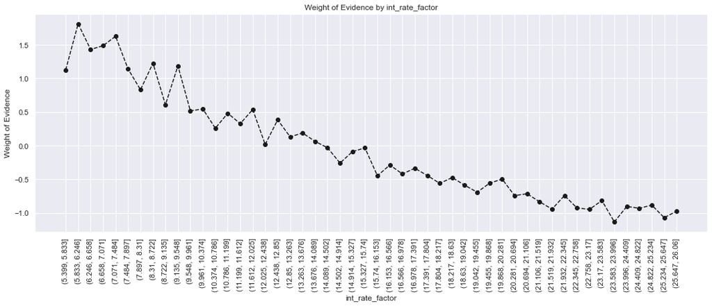

```python
# We plot the weight of evidence values.
# Labels are rotated by 90 degres
plot_by_woe(df_temp, 90)
```

```python
# We retain these categories: '< 9.548', '9.548 - 12.025', '12.025 - 15.74', '15.74 - 20.281', '> 20.281'
df_inputs_prepr['int_rate:<9.548'] = np.where((df_inputs_prepr['int_rate'] <= 9.548), 1, 0)
df_inputs_prepr['int_rate:9.548-12.025'] = np.where((df_inputs_prepr['int_rate'] > 9.548) & (df_inputs_prepr['int_rate'] <= 12.025), 1, 0)
df_inputs_prepr['int_rate:12.025-15.74'] = np.where((df_inputs_prepr['int_rate'] > 12.025) & (df_inputs_prepr['int_rate'] <= 15.74), 1, 0)
df_inputs_prepr['int_rate:15.74-20.281'] = np.where((df_inputs_prepr['int_rate'] > 15.74) & (df_inputs_prepr['int_rate'] <= 20.281), 1, 0)
df_inputs_prepr['int_rate:>20.281'] = np.where((df_inputs_prepr['int_rate'] > 20.281), 1, 0)
```

```python
# Looking at "funded_amnt"
# Here we do fine-classing: using the 'cut' method, we split the variable into 50 categories by its values.
df_inputs_prepr['funded_amnt_factor'] = pd.cut(df_inputs_prepr['funded_amnt'], 50)
# We calculate weight of evidence.
df_temp = woe_ordered_continuous(df_inputs_prepr, 'funded_amnt_factor', df_targets_prepr)
df_temp
```

|  | funded_amnt_factor | n_obs | prop_good | prop_n_obs | n_good | n_bad | prop_n_good | prop_n_bad | WoE | diff_prop_good | diff_WoE | IV |
| --- | --- | --- | --- | --- | --- | --- | --- | --- | --- | --- | --- | --- |
| 0 | (465.5, 1190.0] | 1224 | 0.905229 | 0.003281 | 1108.0 | 116.0 | 0.003335 | 0.002845 | 0.158977 | NaN | NaN | 0.014139 |
| 1 | (1190.0, 1880.0] | 3028 | 0.903897 | 0.008117 | 2737.0 | 291.0 | 0.008238 | 0.007136 | 0.143549 | 0.001332 | 0.015427 | 0.014139 |
| 2 | (1880.0, 2570.0] | 6018 | 0.893819 | 0.016133 | 5379.0 | 639.0 | 0.016190 | 0.015670 | 0.032608 | 0.010078 | 0.110941 | 0.014139 |
| 3 | (2570.0, 3260.0] | 7248 | 0.889073 | 0.019430 | 6444.0 | 804.0 | 0.019395 | 0.019717 | -0.016440 | 0.004746 | 0.049048 | 0.014139 |
| 4 | (3260.0, 3950.0] | 4751 | 0.891602 | 0.012736 | 4236.0 | 515.0 | 0.012749 | 0.012629 | 0.009463 | 0.002529 | 0.025902 | 0.014139 |
| 5 | (3950.0, 4640.0] | 9023 | 0.890945 | 0.024189 | 8039.0 | 984.0 | 0.024196 | 0.024131 | 0.002689 | 0.000656 | 0.006774 | 0.014139 |
| 6 | (4640.0, 5330.0] | 15903 | 0.892159 | 0.042632 | 14188.0 | 1715.0 | 0.042703 | 0.042057 | 0.015238 | 0.001213 | 0.012549 | 0.014139 |
| 7 | (5330.0, 6020.0] | 17236 | 0.906069 | 0.046206 | 15617.0 | 1619.0 | 0.047004 | 0.039703 | 0.168806 | 0.013910 | 0.153568 | 0.014139 |
| 8 | (6020.0, 6710.0] | 6914 | 0.887619 | 0.018535 | 6137.0 | 777.0 | 0.018471 | 0.019054 | -0.031094 | 0.018449 | 0.199900 | 0.014139 |
| 9 | (6710.0, 7400.0] | 11806 | 0.898018 | 0.031649 | 10602.0 | 1204.0 | 0.031910 | 0.029526 | 0.077648 | 0.010399 | 0.108742 | 0.014139 |
| 10 | (7400.0, 8090.0] | 17692 | 0.897355 | 0.047428 | 15876.0 | 1816.0 | 0.047783 | 0.044534 | 0.070427 | 0.000663 | 0.007221 | 0.014139 |
| 11 | (8090.0, 8780.0] | 6316 | 0.879512 | 0.016932 | 5555.0 | 761.0 | 0.016719 | 0.018662 | -0.109925 | 0.017842 | 0.180352 | 0.014139 |
| 12 | (8780.0, 9470.0] | 9168 | 0.880345 | 0.024577 | 8071.0 | 1097.0 | 0.024292 | 0.026902 | -0.102047 | 0.000832 | 0.007878 | 0.014139 |
| 13 | (9470.0, 10160.0] | 33410 | 0.895001 | 0.089564 | 29902.0 | 3508.0 | 0.089998 | 0.086027 | 0.045134 | 0.014657 | 0.147181 | 0.014139 |
| 14 | (10160.0, 10850.0] | 6755 | 0.872835 | 0.018109 | 5896.0 | 859.0 | 0.017746 | 0.021065 | -0.171484 | 0.022167 | 0.216619 | 0.014139 |
| 15 | (10850.0, 11540.0] | 8559 | 0.882697 | 0.022945 | 7555.0 | 1004.0 | 0.022739 | 0.024621 | -0.079527 | 0.009862 | 0.091957 | 0.014139 |
| 16 | (11540.0, 12230.0] | 23506 | 0.902493 | 0.063014 | 21214.0 | 2292.0 | 0.063850 | 0.056207 | 0.127492 | 0.019796 | 0.207019 | 0.014139 |
| 17 | (12230.0, 12920.0] | 4802 | 0.875052 | 0.012873 | 4202.0 | 600.0 | 0.012647 | 0.014714 | -0.151359 | 0.027441 | 0.278850 | 0.014139 |
| 18 | (12920.0, 13610.0] | 7247 | 0.894853 | 0.019427 | 6485.0 | 762.0 | 0.019518 | 0.018687 | 0.043556 | 0.019801 | 0.194914 | 0.014139 |
| 19 | (13610.0, 14300.0] | 8123 | 0.892774 | 0.021776 | 7252.0 | 871.0 | 0.021827 | 0.021360 | 0.021646 | 0.002079 | 0.021910 | 0.014139 |
| 20 | (14300.0, 14990.0] | 5183 | 0.874976 | 0.013894 | 4535.0 | 648.0 | 0.013649 | 0.015891 | -0.152055 | 0.017798 | 0.173701 | 0.014139 |
| 21 | (14990.0, 15680.0] | 21757 | 0.899297 | 0.058325 | 19566.0 | 2191.0 | 0.058889 | 0.053730 | 0.091690 | 0.024321 | 0.243746 | 0.014139 |
| 22 | (15680.0, 16370.0] | 11788 | 0.884119 | 0.031601 | 10422.0 | 1366.0 | 0.031368 | 0.033498 | -0.065713 | 0.015177 | 0.157403 | 0.014139 |
| 23 | (16370.0, 17060.0] | 6538 | 0.876721 | 0.017527 | 5732.0 | 806.0 | 0.017252 | 0.019766 | -0.136009 | 0.007399 | 0.070296 | 0.014139 |
| 24 | (17060.0, 17750.0] | 3422 | 0.866745 | 0.009174 | 2966.0 | 456.0 | 0.008927 | 0.011183 | -0.225268 | 0.009976 | 0.089259 | 0.014139 |
| 25 | (17750.0, 18440.0] | 11441 | 0.885062 | 0.030671 | 10126.0 | 1315.0 | 0.030477 | 0.032248 | -0.056475 | 0.018318 | 0.168793 | 0.014139 |
| 26 | (18440.0, 19130.0] | 3919 | 0.869099 | 0.010506 | 3406.0 | 513.0 | 0.010251 | 0.012580 | -0.204727 | 0.015963 | 0.148252 | 0.014139 |
| 27 | (19130.0, 19820.0] | 4004 | 0.857393 | 0.010734 | 3433.0 | 571.0 | 0.010333 | 0.014003 | -0.303944 | 0.011707 | 0.099217 | 0.014139 |
| 28 | (19820.0, 20510.0] | 20287 | 0.898999 | 0.054385 | 18238.0 | 2049.0 | 0.054892 | 0.050248 | 0.088410 | 0.041607 | 0.392355 | 0.014139 |
| 29 | (20510.0, 21200.0] | 6712 | 0.896305 | 0.017993 | 6016.0 | 696.0 | 0.018107 | 0.017068 | 0.059083 | 0.002694 | 0.029327 | 0.014139 |
| 30 | (21200.0, 21890.0] | 2081 | 0.851514 | 0.005579 | 1772.0 | 309.0 | 0.005333 | 0.007578 | -0.351222 | 0.044791 | 0.410305 | 0.014139 |
| 31 | (21890.0, 22580.0] | 4114 | 0.889645 | 0.011029 | 3660.0 | 454.0 | 0.011016 | 0.011133 | -0.010624 | 0.038131 | 0.340598 | 0.014139 |
| 32 | (22580.0, 23270.0] | 2445 | 0.885072 | 0.006554 | 2164.0 | 281.0 | 0.006513 | 0.006891 | -0.056386 | 0.004574 | 0.045762 | 0.014139 |
| 33 | (23270.0, 23960.0] | 1825 | 0.844932 | 0.004892 | 1542.0 | 283.0 | 0.004641 | 0.006940 | -0.402356 | 0.040140 | 0.345970 | 0.014139 |
| 34 | (23960.0, 24650.0] | 9836 | 0.904331 | 0.026368 | 8895.0 | 941.0 | 0.026772 | 0.023076 | 0.148556 | 0.059400 | 0.550913 | 0.014139 |
| 35 | (24650.0, 25340.0] | 10074 | 0.889815 | 0.027006 | 8964.0 | 1110.0 | 0.026980 | 0.027221 | -0.008888 | 0.014516 | 0.157445 | 0.014139 |
| 36 | (25340.0, 26030.0] | 1832 | 0.868450 | 0.004911 | 1591.0 | 241.0 | 0.004789 | 0.005910 | -0.210424 | 0.021366 | 0.201535 | 0.014139 |
| 37 | (26030.0, 26720.0] | 1252 | 0.835463 | 0.003356 | 1046.0 | 206.0 | 0.003148 | 0.005052 | -0.472893 | 0.032987 | 0.262469 | 0.014139 |
| 38 | (26720.0, 27410.0] | 1510 | 0.873510 | 0.004048 | 1319.0 | 191.0 | 0.003970 | 0.004684 | -0.165389 | 0.038047 | 0.307503 | 0.014139 |
| 39 | (27410.0, 28100.0] | 6457 | 0.907078 | 0.017310 | 5857.0 | 600.0 | 0.017628 | 0.014714 | 0.180718 | 0.033568 | 0.346107 | 0.014139 |
| 40 | (28100.0, 28790.0] | 795 | 0.854088 | 0.002131 | 679.0 | 116.0 | 0.002044 | 0.002845 | -0.330714 | 0.052990 | 0.511432 | 0.014139 |
| 41 | (28790.0, 29480.0] | 1176 | 0.866497 | 0.003153 | 1019.0 | 157.0 | 0.003067 | 0.003850 | -0.227414 | 0.012409 | 0.103300 | 0.014139 |
| 42 | (29480.0, 30170.0] | 7308 | 0.884647 | 0.019591 | 6465.0 | 843.0 | 0.019458 | 0.020673 | -0.060554 | 0.018150 | 0.166860 | 0.014139 |
| 43 | (30170.0, 30860.0] | 567 | 0.825397 | 0.001520 | 468.0 | 99.0 | 0.001409 | 0.002428 | -0.544397 | 0.059250 | 0.483843 | 0.014139 |
| 44 | (30860.0, 31550.0] | 884 | 0.883484 | 0.002370 | 781.0 | 103.0 | 0.002351 | 0.002526 | -0.071899 | 0.058087 | 0.472498 | 0.014139 |
| 45 | (31550.0, 32240.0] | 1326 | 0.872549 | 0.003555 | 1157.0 | 169.0 | 0.003482 | 0.004144 | -0.174058 | 0.010935 | 0.102159 | 0.014139 |
| 46 | (32240.0, 32930.0] | 631 | 0.874802 | 0.001692 | 552.0 | 79.0 | 0.001661 | 0.001937 | -0.153645 | 0.002253 | 0.020413 | 0.014139 |
| 47 | (32930.0, 33620.0] | 1090 | 0.895413 | 0.002922 | 976.0 | 114.0 | 0.002938 | 0.002796 | 0.049519 | 0.020611 | 0.203164 | 0.014139 |
| 48 | (33620.0, 34310.0] | 492 | 0.890244 | 0.001319 | 438.0 | 54.0 | 0.001318 | 0.001324 | -0.004510 | 0.005169 | 0.054029 | 0.014139 |
| 49 | (34310.0, 35000.0] | 13553 | 0.883199 | 0.036332 | 11970.0 | 1583.0 | 0.036027 | 0.038820 | -0.074663 | 0.007045 | 0.070153 | 0.014139 |

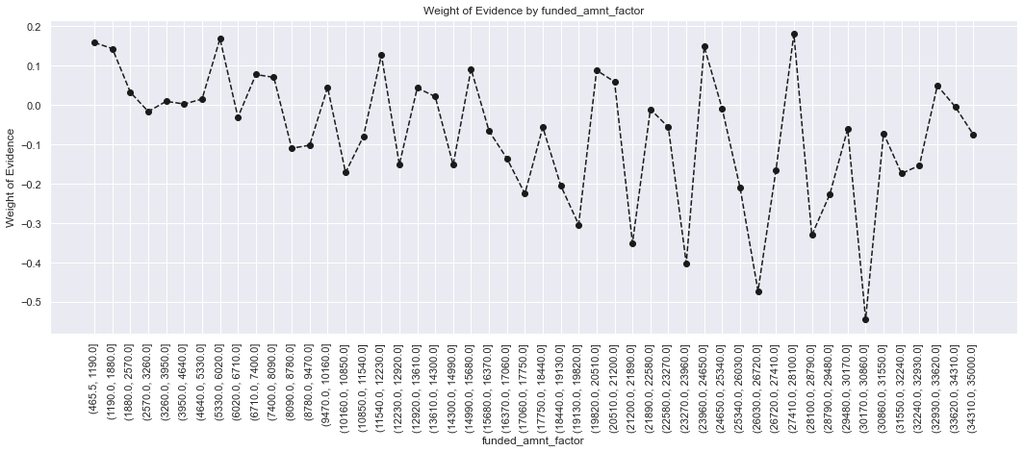

```python
# We plot the weight of evidence values.
plot_by_woe(df_temp, 90)
```

```python
## Looking at 'mths_since_earliest_cr_line'
# Here we do fine-classing: using the 'cut' method, we split the variable into 50 categories by its values.
df_inputs_prepr['mths_since_earliest_cr_line_factor'] = pd.cut(df_inputs_prepr['mths_since_earliest_cr_line'], 50)
# We calculate weight of evidence.
df_temp = woe_ordered_continuous(df_inputs_prepr, 'mths_since_earliest_cr_line_factor', df_targets_prepr)
df_temp
```

|  | mths_since_earliest_cr_line_factor | n_obs | prop_good | prop_n_obs | n_good | n_bad | prop_n_good | prop_n_bad | WoE | diff_prop_good | diff_WoE | IV |
| --- | --- | --- | --- | --- | --- | --- | --- | --- | --- | --- | --- | --- |
| 0 | (-0.924, 18.48] | 24 | 0.875000 | 0.000064 | 21.0 | 3.0 | 0.000063 | 0.000074 | -0.151835 | NaN | NaN | inf |
| 1 | (18.48, 36.96] | 0 | NaN | 0.000000 | NaN | NaN | NaN | NaN | NaN | NaN | NaN | inf |
| 2 | (36.96, 55.44] | 0 | NaN | 0.000000 | NaN | NaN | NaN | NaN | NaN | NaN | NaN | inf |
| 3 | (55.44, 73.92] | 0 | NaN | 0.000000 | NaN | NaN | NaN | NaN | NaN | NaN | NaN | inf |
| 4 | (73.92, 92.4] | 0 | NaN | 0.000000 | NaN | NaN | NaN | NaN | NaN | NaN | NaN | inf |
| 5 | (92.4, 110.88] | 2 | 1.000000 | 0.000005 | 2.0 | 0.0 | 0.000006 | 0.000000 | inf | NaN | NaN | inf |
| 6 | (110.88, 129.36] | 2470 | 0.890688 | 0.006621 | 2200.0 | 270.0 | 0.006622 | 0.006621 | 0.000046 | 0.109312 | inf | inf |
| 7 | (129.36, 147.84] | 4500 | 0.864444 | 0.012063 | 3890.0 | 610.0 | 0.011708 | 0.014959 | -0.245039 | 0.026244 | 0.245085 | inf |
| 8 | (147.84, 166.32] | 12805 | 0.865443 | 0.034327 | 11082.0 | 1723.0 | 0.033354 | 0.042253 | -0.236490 | 0.000999 | 0.008550 | inf |
| 9 | (166.32, 184.8] | 19689 | 0.871349 | 0.052782 | 17156.0 | 2533.0 | 0.051636 | 0.062117 | -0.184801 | 0.005906 | 0.051688 | inf |
| 10 | (184.8, 203.28] | 24458 | 0.876482 | 0.065566 | 21437.0 | 3021.0 | 0.064521 | 0.074084 | -0.138214 | 0.005133 | 0.046587 | inf |
| 11 | (203.28, 221.76] | 31728 | 0.886945 | 0.085055 | 28141.0 | 3587.0 | 0.084698 | 0.087964 | -0.037834 | 0.010463 | 0.100381 | inf |
| 12 | (221.76, 240.24] | 40017 | 0.884199 | 0.107276 | 35383.0 | 4634.0 | 0.106495 | 0.113640 | -0.064934 | 0.002746 | 0.027100 | inf |
| 13 | (240.24, 258.72] | 43197 | 0.886150 | 0.115801 | 38279.0 | 4918.0 | 0.115211 | 0.120604 | -0.045745 | 0.001950 | 0.019188 | inf |
| 14 | (258.72, 277.2] | 35444 | 0.887597 | 0.095017 | 31460.0 | 3984.0 | 0.094688 | 0.097700 | -0.031314 | 0.001448 | 0.014431 | inf |
| 15 | (277.2, 295.68] | 28044 | 0.893703 | 0.075179 | 25063.0 | 2981.0 | 0.075434 | 0.073103 | 0.031389 | 0.006105 | 0.062703 | inf |
| 16 | (295.68, 314.16] | 27409 | 0.895801 | 0.073477 | 24553.0 | 2856.0 | 0.073899 | 0.070038 | 0.053667 | 0.002098 | 0.022278 | inf |
| 17 | (314.16, 332.64] | 21516 | 0.904025 | 0.057679 | 19451.0 | 2065.0 | 0.058543 | 0.050640 | 0.145023 | 0.008224 | 0.091356 | inf |
| 18 | (332.64, 351.12] | 14559 | 0.905351 | 0.039029 | 13181.0 | 1378.0 | 0.039672 | 0.033793 | 0.160398 | 0.001326 | 0.015375 | inf |
| 19 | (351.12, 369.6] | 12772 | 0.904557 | 0.034239 | 11553.0 | 1219.0 | 0.034772 | 0.029894 | 0.151169 | 0.000794 | 0.009229 | inf |
| 20 | (369.6, 388.08] | 12221 | 0.903199 | 0.032762 | 11038.0 | 1183.0 | 0.033222 | 0.029011 | 0.135545 | 0.001357 | 0.015624 | inf |
| 21 | (388.08, 406.56] | 8948 | 0.911600 | 0.023987 | 8157.0 | 791.0 | 0.024551 | 0.019398 | 0.235589 | 0.008401 | 0.100043 | inf |
| 22 | (406.56, 425.04] | 7589 | 0.909606 | 0.020344 | 6903.0 | 686.0 | 0.020777 | 0.016823 | 0.211089 | 0.001994 | 0.024500 | inf |
| 23 | (425.04, 443.52] | 6206 | 0.905736 | 0.016637 | 5621.0 | 585.0 | 0.016918 | 0.014346 | 0.164908 | 0.003870 | 0.046181 | inf |
| 24 | (443.52, 462.0] | 4843 | 0.910799 | 0.012983 | 4411.0 | 432.0 | 0.013276 | 0.010594 | 0.225686 | 0.005063 | 0.060778 | inf |
| 25 | (462.0, 480.48] | 3025 | 0.917355 | 0.008109 | 2775.0 | 250.0 | 0.008352 | 0.006131 | 0.309200 | 0.006556 | 0.083514 | inf |
| 26 | (480.48, 498.96] | 2467 | 0.910012 | 0.006613 | 2245.0 | 222.0 | 0.006757 | 0.005444 | 0.216038 | 0.007343 | 0.093162 | inf |
| 27 | (498.96, 517.44] | 2522 | 0.911578 | 0.006761 | 2299.0 | 223.0 | 0.006919 | 0.005469 | 0.235313 | 0.001566 | 0.019274 | inf |
| 28 | (517.44, 535.92] | 1777 | 0.910523 | 0.004764 | 1618.0 | 159.0 | 0.004870 | 0.003899 | 0.222297 | 0.001055 | 0.013016 | inf |
| 29 | (535.92, 554.4] | 1242 | 0.917069 | 0.003330 | 1139.0 | 103.0 | 0.003428 | 0.002526 | 0.305432 | 0.006546 | 0.083135 | inf |
| 30 | (554.4, 572.88] | 934 | 0.907923 | 0.002504 | 848.0 | 86.0 | 0.002552 | 0.002109 | 0.190788 | 0.009146 | 0.114644 | inf |
| 31 | (572.88, 591.36] | 810 | 0.911111 | 0.002171 | 738.0 | 72.0 | 0.002221 | 0.001766 | 0.229533 | 0.003188 | 0.038744 | inf |
| 32 | (591.36, 609.84] | 472 | 0.891949 | 0.001265 | 421.0 | 51.0 | 0.001267 | 0.001251 | 0.013062 | 0.019162 | 0.216471 | inf |
| 33 | (609.84, 628.32] | 464 | 0.911638 | 0.001244 | 423.0 | 41.0 | 0.001273 | 0.001005 | 0.236055 | 0.019689 | 0.222993 | inf |
| 34 | (628.32, 646.8] | 303 | 0.861386 | 0.000812 | 261.0 | 42.0 | 0.000786 | 0.001030 | -0.270894 | 0.050252 | 0.506949 | inf |
| 35 | (646.8, 665.28] | 215 | 0.883721 | 0.000576 | 190.0 | 25.0 | 0.000572 | 0.000613 | -0.069597 | 0.022335 | 0.201297 | inf |
| 36 | (665.28, 683.76] | 134 | 0.843284 | 0.000359 | 113.0 | 21.0 | 0.000340 | 0.000515 | -0.414880 | 0.040437 | 0.345283 | inf |
| 37 | (683.76, 702.24] | 91 | 0.890110 | 0.000244 | 81.0 | 10.0 | 0.000244 | 0.000245 | -0.005881 | 0.046826 | 0.408999 | inf |
| 38 | (702.24, 720.72] | 43 | 0.930233 | 0.000115 | 40.0 | 3.0 | 0.000120 | 0.000074 | 0.492522 | 0.040123 | 0.498403 | inf |
| 39 | (720.72, 739.2] | 42 | 0.880952 | 0.000113 | 37.0 | 5.0 | 0.000111 | 0.000123 | -0.096265 | 0.049280 | 0.588787 | inf |
| 40 | (739.2, 757.68] | 13 | 0.923077 | 0.000035 | 12.0 | 1.0 | 0.000036 | 0.000025 | 0.387162 | 0.042125 | 0.483427 | inf |
| 41 | (757.68, 776.16] | 8 | 0.750000 | 0.000021 | 6.0 | 2.0 | 0.000018 | 0.000049 | -0.999133 | 0.173077 | 1.386294 | inf |
| 42 | (776.16, 794.64] | 10 | 0.700000 | 0.000027 | 7.0 | 3.0 | 0.000021 | 0.000074 | -1.250447 | 0.050000 | 0.251314 | inf |
| 43 | (794.64, 813.12] | 3 | 1.000000 | 0.000008 | 3.0 | 0.0 | 0.000009 | 0.000000 | inf | 0.300000 | inf | inf |
| 44 | (813.12, 831.6] | 2 | 1.000000 | 0.000005 | 2.0 | 0.0 | 0.000006 | 0.000000 | inf | 0.000000 | NaN | inf |
| 45 | (831.6, 850.08] | 5 | 1.000000 | 0.000013 | 5.0 | 0.0 | 0.000015 | 0.000000 | inf | 0.000000 | NaN | inf |
| 46 | (850.08, 868.56] | 1 | 1.000000 | 0.000003 | 1.0 | 0.0 | 0.000003 | 0.000000 | inf | 0.000000 | NaN | inf |
| 47 | (868.56, 887.04] | 1 | 1.000000 | 0.000003 | 1.0 | 0.0 | 0.000003 | 0.000000 | inf | 0.000000 | NaN | inf |
| 48 | (887.04, 905.52] | 2 | 1.000000 | 0.000005 | 2.0 | 0.0 | 0.000006 | 0.000000 | inf | 0.000000 | NaN | inf |
| 49 | (905.52, 924.0] | 1 | 1.000000 | 0.000003 | 1.0 | 0.0 | 0.000003 | 0.000000 | inf | 0.000000 | NaN | inf |

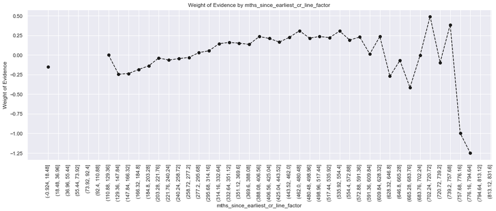

```python
# We plot the weight of evidence values.
plot_by_woe(df_temp, 90)
```